# Basics of R Programming Language

## R!

R is a powerful programming language and open-source software widely used for statistical computing and data analysis. This programming language is developed by Ross Ihaka and Robert Gentleman at the University of Auckland, New Zealand. R has gained popularity among statisticians, data scientists, researchers, and analysts for its flexibility, extensibility, and robust statistical capabilities.

## Why learn R?

Here are several compelling reasons to consider learning R:

- Statistical Analysis
- Data Visualisation
- Open Source
- Community Support
- Extensibility
- Integration with Other Languages
- Data Science and Machine Learning
- Widely Used in Academia and Industry
- Continuous Development

## Getting Started with R

To begin working with R, users typically install an Integrated Development Environment (IDE) such as RStudio, which provides a user-friendly interface for coding, debugging, and visualising results. R scripts are written in the R language and can be executed interactively or saved for later use.

## A look around RStudio

### Console Pane

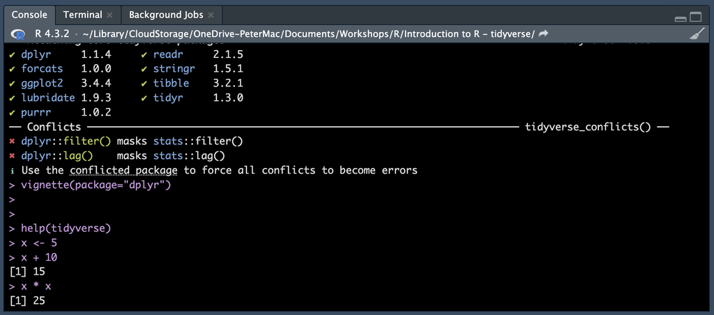

On the left-hand side, you’ll find the *console*. This is where you can input commands (code that R can interpret), and the responses to your commands, known as *output*, are displayed here. While the console is handy for experimenting with code, it doesn’t save any of your entered commands. Therefore, relying exclusively on the console is not recommended.

### History Pane

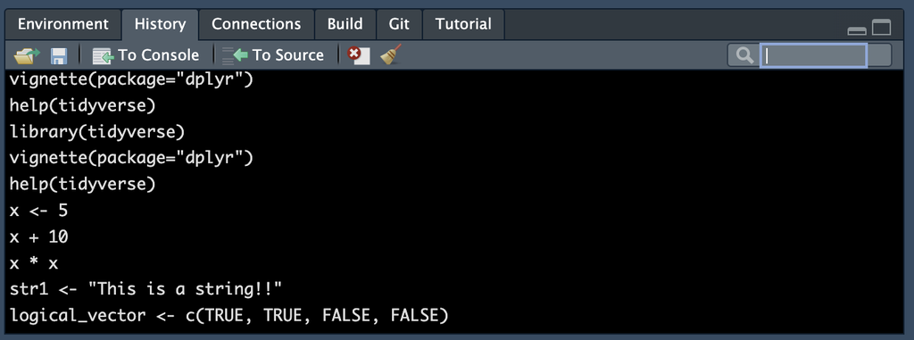

The *history pane* (located in the top right window) maintains a record of the commands that you have executed in the R console during your current R session. This includes both correct and incorrect commands.

You can navigate through your command history using the up and down arrow keys in the *console*. This allows you to quickly recall and re-run previous commands without retyping them.

### Environment Pane

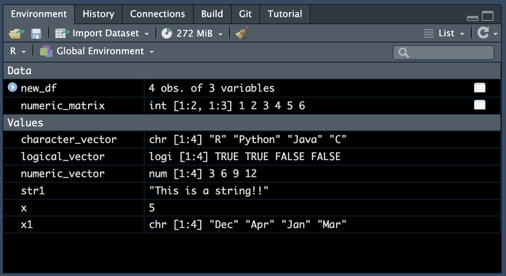

The *environment pane* (located in the top right window) provides an overview of the objects (variables, data frames, etc.) that currently exist in your R session. It displays the names, types, dimensions, and some content of these objects. This allows you to monitor the state of your workspace in real-time.

### Plotting Pane

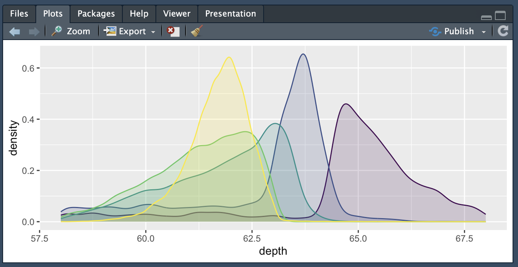

The *plotting pane* (located in the bottom right window) is where graphical output, such as plots and charts, is displayed when you create visualisations in R. The Plotting pane often includes tools for zooming, panning, and exporting plots, providing additional functionality for exploring and customising your visualisations. Help Pane:

### Help Pane

[figure not shown]

The *help pane* (located in the bottom right window) is a valuable resource for accessing documentation and information about R functions, packages, and commands. When you type a function or command in the console and press the F1 key (Mac: fn + F1) the Help pane displays relevant documentation. Additionally, you can type a keyword in the text box at the top right corner of the Help Pane.

### Files Pane

[figure not shown]

The *files pane* provides a file browser and file management interface within RStudio. It allows you to navigate through your project directories, view files, and manage your file system.

### Packages Pane

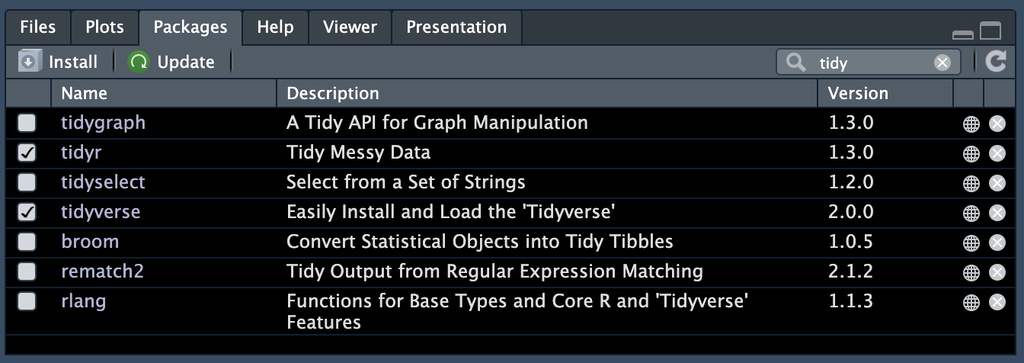

This pane provides a user-friendly interface for managing R packages. It lists installed packages and allows you to load, unload, update, and install packages.

### Viewer Pane

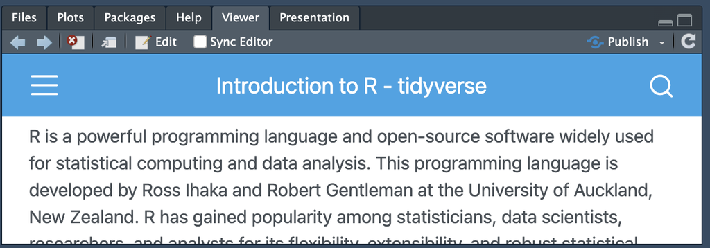

It is used to display dynamic content generated by R, such as HTML, Shiny applications, or interactive visualisations.

## Working directory

Opening an RStudio session launches it from a specific location. This is the *working directory*. R looks in the working directory by default to read in data and save files. You can find out what the working directory is by using the command `getwd()`. This shows you the path to your working directory in the console. In Mac this is in the format `/path/to/working/directory` and in Windows `C:\path\to\working\directory`. It is often useful to have your data and R scripts in the same directory and set this as your working directory. We will do this now.

Make a folder for this course somewhere on your computer that you will be able to easily find. Name the folder for example, `Intro_R_REDCap_course`. Then, to set this folder as your working directory:

In RStudio click on the Files tab and then click on the three dots, as shown below.

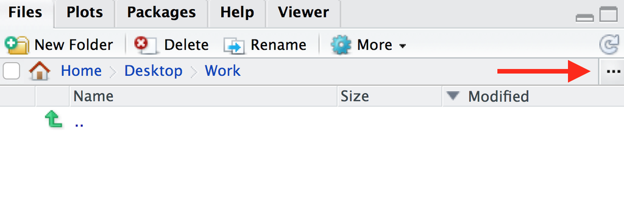

In the window that appears, find the folder you created (e.g. `Intro_R_REDCap_course`), click on it, then click Open. The files tab will now show the contents of your new folder. Click on More → Set As Working Directory, as shown below.

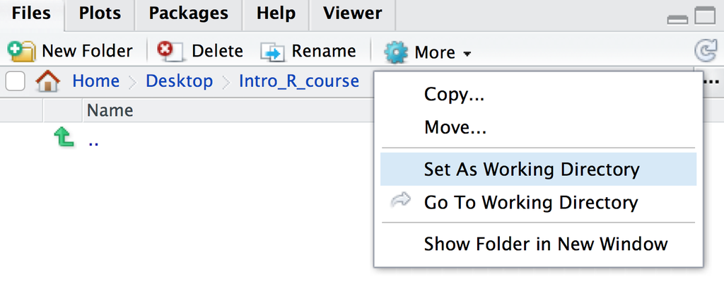

Note: You can use an RStudio project as described here to automatically keep track of and set the working directory.

## R Scripts

In RStudio, the Script pane (located at the top left window) serves as a dedicated space for writing, editing, and executing R scripts. It is where you compose and organise your R code, making it an essential area for creating reproducible and well-documented analyses.

RStudio provides syntax highlighting in the Script pane, making it easier to identify different components of your code. You can execute individual lines or selections of code from the Script pane. This helps in testing and debugging code without running the entire script.

## Quarto Document

Quarto is an open-source scientific and technical publishing system that allows you to combine text, code, and output in a single document. It is the next-generation version of RMarkdown and is widely used for reproducible research, dynamic reports, and interactive documents.

With Quarto, you can:

- Write reports that integrate R code and results
- Create interactive documents (HTML, PDF, Word, and more)
- Publish research outputs with dynamic figures and tables

Why use Quarto?

- Reproducibility
- Combines analysis and documentation in one file
- Flexible Outputs
- Generate HTML, PDF, Word, and presentations
- Works with R, Python, and Julia
- Supports Markdown Syntax
- Easy formatting for text and visuals

In this workshop, we will be using Quarto documents to write R code.

### Getting Started with a Quarto Document

Follow these steps to create a new Quarto document in RStudio:

#### Open a New Quarto Document

1. Open RStudio
2. Go to File → New File → Quarto Document
3. A dialog box will appear:
   - Title: Enter a document title as “Analysing REDCap Data using R”
   - Format: Leave default format as HTML
   - Engine: Leave default engine as knitr
4. Click Create.

This creates a new .qmd file in RStudio, which is a Quarto document.

#### Save the File

1. Click File → Save As
2. Choose a meaningful filename, e.g., introR_workshop.qmd
3. Click Save

#### Understanding the Structure of a Quarto Document

A Quarto document consists of three main sections:

1. **YAML Header (Metadata Section)**

This section is enclosed at the top of the file using — and contains metadata. Example:

```r
---
title: "My First Quarto Document"
author: "John Doe"
date: "2025-01-30"
format: html
---
```

Common YAML options:

- title: Document title
- author: Name of the author
- date: Date of the document
- format: Output type (HTML, PDF, Word, etc.)
2. **Text and Markdown (Narrative Section)**

Quarto supports Markdown, a simple way to format text.

- Headings:

  ```
  # Main Heading
  ## Subheading
  ### Smaller Heading
  ```

- Bold and Italic Text:

  ```
  **Bold Text**
  *Italic Text*
  ```

- Lists:

  ```
  -   Bullet Point 1
  -   Bullet Point 2
  ```

- Hyperlinks and Images:

  ```
  [Click here for Quarto docs](https://quarto.org/)
  ![RStudio Logo](https://www.rstudio.com/wp-content/uploads/2014/04/rstudio-logo.png)
  ```

3. **Code Blocks (Executable Section)**

Quarto allows you to insert code chunks that run R scripts inside your document.

Example R Code Chunk:

```{r}  
# Example calculation  
x <- c(1, 2, 3, 4, 5)  
sum(x)  
```

To insert a code chunk, go to Code in the menu -> Insert Code Chunk or use the keyboard shortcuts **Windows/Linux**: `Ctrl` + `Alt` + `I` or **Mac**: `⌘` + `Option` + `I`. Code is written inside triple backticks and it is executed when you render the document.

4. **Running and Rendering a Quarto Document**

To run a single code chunk click the **Run** button at the top of the chunk or use the keyboard shortcut **Windows/Linux**: `Ctrl` + `Shift` + `Enter` or **Mac**: `⌘` + `Shift` + `Enter`.

To generate an output file (HTML, PDF, or Word), click the **Render** button in RStudio. The document compiles and opens the rendered file.

**Tip**

If PDF output fails, install `TinyTeX` for `LaTeX` support:

```r
install.packages("tinytex")
```

#### Keyboard Shortcuts in Quarto (Windows & Mac)

| **Action** | **Windows/Linux** | **Mac** |
| --- | --- | --- |
| Run a single code line | `Ctrl + Enter` | `Cmd + Enter` |
| Run a single code chunk | `Ctrl + Shift + Enter` | `Cmd + Shift + Enter` |
| Run all chunks above | `Ctrl + Alt + P` | `Cmd + Option + P` |
| Render (Knit) document | `Ctrl + Shift + K` | `Cmd + Shift + K` |
| Insert a new code chunk | `Ctrl + Alt + I` | `Cmd + Option + I` |
| Comment/uncomment a line | `Ctrl + Shift + C` | `Cmd + Shift + C` |
| Open Quarto Render menu | `Ctrl + Shift + R` | `Cmd + Shift + R` |
| Open Quarto preview | `Ctrl + Shift + O` | `Cmd + Shift + O` |
| Restart R session | `Ctrl + Shift + F10` | `Cmd + Shift + F10` |

## Comments

In R, any text following the hash symbol # is termed a *comment*. R disregards this text, considering it non-executable. Comments serve the purpose of documenting your code, aiding your future understanding of specific lines, and highlighting the intentions or challenges encountered.

RStudio makes it easy to comment or uncomment a paragraph: Select the lines you want to comment (to comment a set of lines) or placing the cursor at any location of a line (to comment a single line), press at the same time on your keyboard `⌘` + `Shift` + `C` (mac) or `Ctrl` + `Shift` + `C` (Windows/Linux).

Extensive use of comments is encouraged throughout this course.

```
# This is a comment. Ignored by R. But useful for me!
```

## Executing Commands

Executing commands or *running code* is the process of submitting a command to your computer, which does some computation and returns an answer. In RStudio, there are several ways to execute commands:

- Select the line(s) of code using the mouse, and then click **Run** at the top right corner of the R text file.
- Select **Run Lines** from the Code menu.
- Click anywhere on the line of code and click **Run**.
- Select the line(s) you want to run. Press `⌘` + `Return` (Mac) or `Ctrl` + `Return` (Windows/Linux) to run the selected code.

When you type in, and then run the commands shown in the grey boxes below, you should see the result in the Console pane at bottom left.

### Simple Maths in R

We can use R as a calculator to do simple maths.

```r
3 + 5
```

```
[1] 8
```

More complex calculator functions are *built in* to R, which is the reason it is popular among mathematicians and statisticians. To use these functions, we need to call these functions.

### Calling Functions

R has a large collection of built-in functions that are called like this:

```r
function_name(argument1 = value1, argument2 = value2, ...)
```

Let’s explore using `seq()` function to create a series of numbers.

```r
seq(1, 10)
```

```
 [1]  1  2  3  4  5  6  7  8  9 10
```

You can explicitly specify arguments using the `name = value` format. However, if you don’t, R will try to resolve them based on their position.

```r
seq(from = 1, to = 10)
```

```
 [1]  1  2  3  4  5  6  7  8  9 10
```

In this example, it assumes that we want a sequence starting from 1 and ending at 10. Since we didn’t mention the step size, it defaults to the value defined in the function, which is 1 in this case.

```r
seq(from = 1, to = 10, by = 2)
```

```
[1] 1 3 5 7 9
```

If you are using `name = value` format the order of the arguments **does not** matter.

```r
seq(to = 10, by = 2, from = 1)
```

```
[1] 1 3 5 7 9
```

For frequently used functions, I might rely on positional resolution for the first one or two arguments. However, beyond that, I prefer to use the `name = value` format for clarity and precision.

To take the log of 100:

```r
log(x = 100, base = 10)
```

```
[1] 2
```

To take the square root of 100:

```r
sqrt(100) # this is the short-hand of sqrt(x = 100)
```

```
[1] 10
```

Notice that the square root function is abbreviated to `sqrt()`. This is to make writing R code faster, however the draw back is that some functions are hard to remember, or to interpret.

## Getting Help

In R, the `?` and `??` operators are used for accessing help documentation, but they behave slightly differently.

- The `?` operator is used to access help documentation for a specific function or topic. When you type `?` followed by the name of a function, you get detailed information about that function. For example try:

```r
?mean
```

**View Output**

| mean | R Documentation |
| --- | --- |

## Arithmetic Mean

### Description

Generic function for the (trimmed) arithmetic mean.

### Usage

```r
mean(x, ...)

## Default S3 method:
mean(x, trim = 0, na.rm = FALSE, ...)
```

### Arguments

| `x` | An **R** object. Currently there are methods for numeric/logical vectors and date, date-time and time interval objects. Complex vectors are allowed for `trim = 0`, only. |
| --- | --- |
| `trim` | the fraction (0 to 0.5) of observations to be trimmed from each end of `x` before the mean is computed. Values of trim outside that range are taken as the nearest endpoint. |
| `na.rm` | a logical evaluating to `TRUE` or `FALSE` indicating whether `NA` values should be stripped before the computation proceeds. |
| `…` | further arguments passed to or from other methods. |

### Value

If `trim` is zero (the default), the arithmetic mean of the values in `x` is computed, as a numeric or complex vector of length one. If `x` is not logical (coerced to numeric), numeric (including integer) or complex, `NA_real_` is returned, with a warning.

If `trim` is non-zero, a symmetrically trimmed mean is computed with a fraction of `trim` observations deleted from each end before the mean is computed.

### References

Becker, R. A., Chambers, J. M. and Wilks, A. R. (1988) *The New S Language*. Wadsworth & Brooks/Cole.

### See Also

`weighted.mean`, `mean.POSIXct`, `colMeans` for row and column means.

### Examples

```r
x <- c(0:10, 50)
xm <- mean(x)
c(xm, mean(x, trim = 0.10))
```

The above command displays the help documentation for the `mean` function, providing information about its usage, arguments, and examples.

- The `??` operator is used for a broader search across help documentation. It performs a search for the specified term or keyword in the documentation.

```r
??regression
```

This will search for the term “regression” in the help documentation and return relevant results. It’s useful when you want to find functions, packages, or topics related to a specific term.

**Tab completion**

A very useful feature is Tab completion. You can start typing and use `Tab` to autocomplete code, for example, a function name.

## R Packages

Many developers have built 1000s of functions and shared them with the R user community to help make everyone’s work easier and more efficient. These functions (short programs) are generally packaged up together in (wait for it) *Packages*. For example, the tidyverse package is a compilation of many different functions, all of which help with data transformation and visualisation. Packages also contain data, which is often included to assist new users with learning the available functions.

### Installing Packages

Packages are hosted on repositories, with [CRAN (Comprehensive R Archive Network)](https://cran.r-project.org/web/packages/available_packages_by_date.html) being the primary repository. To install packages from CRAN, you use the `install.packages()` function. For example:

```r
install.packages("tidyverse")
```

This will spit out a lot of text into the console as the package is being installed. Once complete you should have a message:

`The downloaded binary packages are in...` followed by a long directory name.

To remove an installed package:

```r
remove.packages("tidyverse")
```

### Loading Packages

After installation, you need to load a package into your R session using the `library()` function. For example:

```r
library(tidyverse)
```

This makes the functions and datasets from the ‘tidyverse’ package available for use in your current session.

**Tip**

You only need to install a package once. Once installed, you don’t need to reinstall it in subsequent sessions. However, you do need to load the package at the beginning of each R session using the `library()` function before you can utilise its functions and features. This ensures that the package is actively available for use in your current session.

To view packages currently loaded into memory:

```r
(.packages())
```

```
 [1] "lubridate" "forcats"   "stringr"   "dplyr"     "purrr"     "readr"
 [7] "tidyr"     "tibble"    "ggplot2"   "tidyverse" "stats"     "graphics"
[13] "grDevices" "utils"     "datasets"  "methods"   "base"
```

```r
search()
```

```
 [1] ".GlobalEnv"        "package:lubridate" "package:forcats"
 [4] "package:stringr"   "package:dplyr"     "package:purrr"
 [7] "package:readr"     "package:tidyr"     "package:tibble"
[10] "package:ggplot2"   "package:tidyverse" "package:stats"
[13] "package:graphics"  "package:grDevices" "package:utils"
[16] "package:datasets"  "package:methods"   "Autoloads"
[19] "package:base"
```

### Package Documentation

Each package comes with documentation that explains how to use its functions. You can access this information using the `help()` function or by using `?` before the function name:

```r
help(tidyverse)
```

**View Output**

| tidyverse-package | R Documentation |
| --- | --- |

## tidyverse: Easily Install and Load the ‘Tidyverse’

### Description

[figure not shown]

The ‘tidyverse’ is a set of packages that work in harmony because they share common data representations and ‘API’ design. This package is designed to make it easy to install and load multiple ‘tidyverse’ packages in a single step. Learn more about the ‘tidyverse’ at https://www.tidyverse.org.

### Author(s)

**Maintainer**: Hadley Wickham hadley@rstudio.com

Other contributors:

- RStudio [copyright holder, funder]

### See Also

Useful links:

- https://tidyverse.tidyverse.org
- https://github.com/tidyverse/tidyverse
- Report bugs at https://github.com/tidyverse/tidyverse/issues

or by using `vignette` (if the documentation is in the form of vignettes):

```r
vignette(package="tidyverse")
```

## Variables

A *variable* is a bit of tricky concept, but very important for understanding R. Essentially, a variable is a symbol that we use in place of another value. Usually the other value is a larger/longer form of data. We can tell R to store a lot of data, for example, in a variable named `x`. When we execute the command `x`, R returns all of the data that we stored there.

For now however we’ll just use a tiny data set: the number 5. To store some data in a variable, we need to use a special symbol `<-`, which in our case tells R to assign the value 5 to the variable `x`. This is called the **assignment operator**. To insert the assignment operator press `Option` + `-` (Mac) or `Alt` + `-` (Windows/Linux).

Let’s see how this works.

Create a variable called `x`, that will contain the number 5.

```r
x <- 5
```

R won’t return anything in the console, but note that you now have a new entry in the environment pane. The variable name is at the left (`x`) and the value that is stored in that variable, is displayed on the right (5).

We can now use `x` in place of 5:

```r
x + 10
```

```
[1] 15
```

```r
x * 3
```

```
[1] 15
```

Variables are sometimes referred to as *objects*. In R there are different conventions about how to name variables, but most importantly they:

- cannot begin with a number
- should begin with an alphabetical letter
- they are case sensitive
- variables can take any name, but its best to use something that makes sense to you, and will likely make sense to others who may read your code.

It is wise to adapt a consistent convention for separating words in variables.

For example:

```r
# i_use_snake_case
# other.people.use.periods
# evenOthersUseCamelCase
```

## Clearing the Environment

Take a look at the objects you have created in your workspace that is accumulated in the environment pane in the upper right corner of RStudio.

[figure not shown]

You can obtain a list of objects in your workspace using a couple of different R commands:

```r
objects()
```

**Output**

```
[1] "x"
```

```r
ls()
```

**Output**

```
[1] "x"
```

If you wish to remove a specific object, let’s say `x1`, you can use the following command:

```r
rm(x1)
```

To remove all objects:

```r
rm(list = ls())
```

Alternatively, you can click the broom icon in RStudio’s Environment pane to clear everything.

For the sake of reproducibility, it’s crucial to regularly delete your objects and restart your R session. This ensures that your analysis can be replicated next week or even after upgrading your operating system. Restarting your R session helps identify and address any dependencies or configurations needed for your analysis to run successfully.

# Case Study: Immunotherapy Dataset

In this workshop, we are using a dummy Immunotherapy dataset on REDCap filled with randomly generated data. Therefore, note that in some cases the data can make no sense. However, this will be useful for learning how to import data into R, data manipulation and basic visualisation.

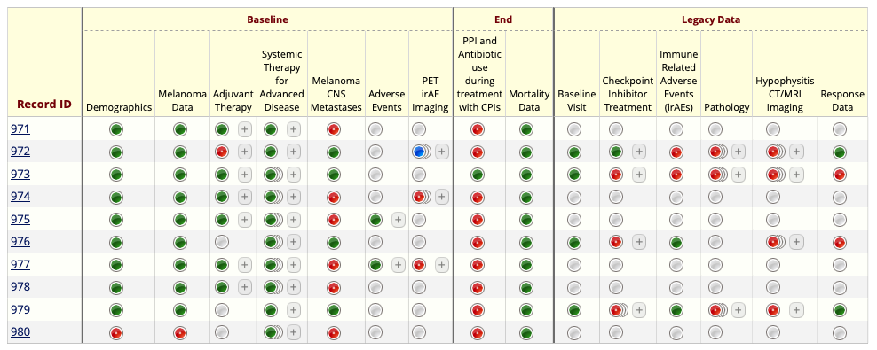

# Importing REDCap Data

## REDCap API

**REDCap** (Research Electronic Data Capture) provides an Application Programming Interface (API) that allows users to programmatically access and interact with their project data. The API enables automation of data retrieval, updates, and exports, reducing manual effort and ensuring reproducibility in data analysis.

### What is the REDCap API?

The REDCap API is a web-based service that allows users to interact with REDCap programmatically. Instead of manually downloading CSV files, users can use the API to:

- Retrieve records from a REDCap project
- Import new data or update existing records
- Export metadata (variable names, field types)
- Pull longitudinal and repeating instrument data
- Generate reports dynamically

The API facilitates automated data retrieval, making it a powerful tool for integrating REDCap data into R-based workflows.

**Example Use Case**

A researcher can schedule a daily script in R to pull the latest REDCap data for real-time analysis instead of manually exporting files from the web interface.

### Requesting an API Token in REDCap

To access the API, users must obtain an API token, which is a unique, secure key that authenticates requests. REDCap provides API tokens at the user-project level. This means that if three users on the same project need to use the API, each user will need to individually request an API token. Similarly, if one user wants an API token for three different projects, they will need to request an API token for each project.

**Steps to Request an API Token for a Project:**

1. Log in to REDCap and navigate to your project.
2. If your REDCap project has API access enabled, you will see it in the applications on the left side of the screen as follows. Otherwise contact REDCapServiceDesk@petermac.org.

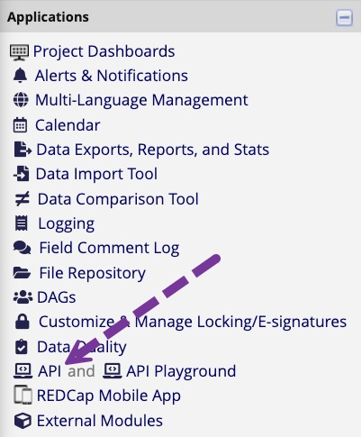

3. Click on “API” under the Applications menu.
4. Click “Request API token” to send a token request to the REDCap administrative team.

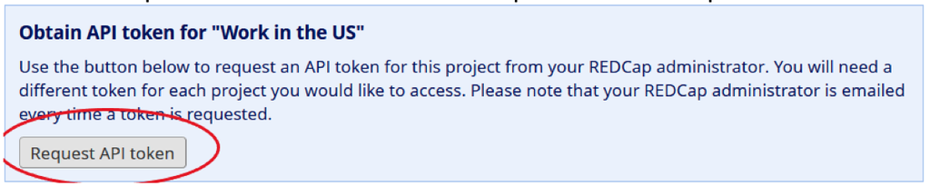

5. Your REDCap administrator will review and approve your request.
6. Once approved, you will receive a unique API token (a long alphanumeric string).

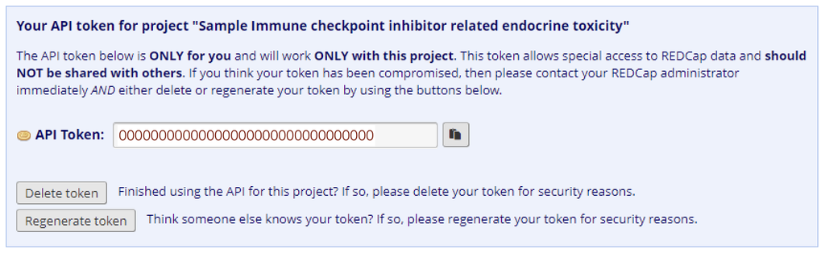

**Important**

Keep your API token private and never share it. It grants full access to your REDCap project data.

### Using the REDCap API

The best way to familiarise yourself with the REDCap API is to explore the API Playground.

1. Click on the “API Playground” link from the left-hand menu under “Applications.”
2. Once in the API Playground, there is a blue box with a dropdown menu labeled “API Method.” This dropdown includes all the API actions REDCap can take.
   1. If a project is in production, the methods listed in this dropdown will be limited so as not to affect real data in the project. This is noted in the green text under the “API Method” dropdown.

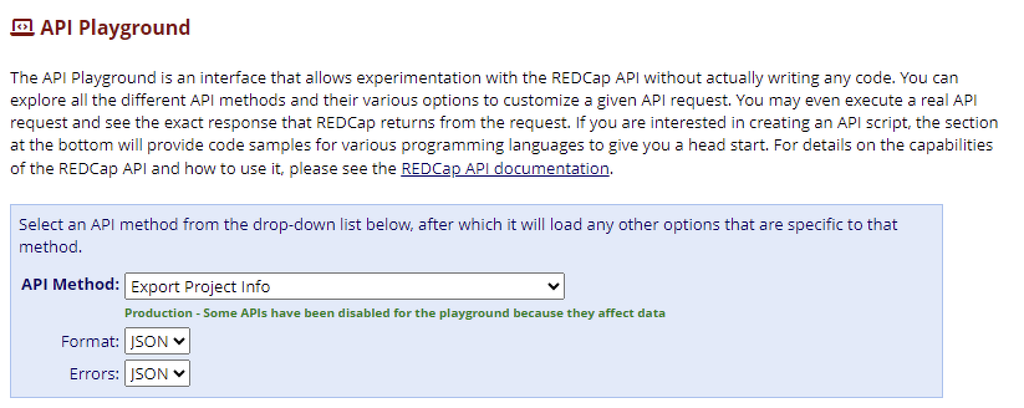

[figure not shown]

5. To execute a real API request, click the “Execute Request” button, and it will display the API response in a textbox as follows.

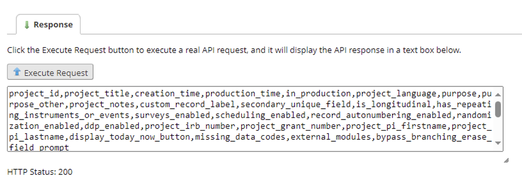

On the API Playground, there is a button that will let you “Execute Request.” This will perform the API action you are programming and thus affect the data in your project. Use this button with a great amount of caution.

**Security Considerations for API Access**

Since the API token provides direct access to your REDCap project, it must be handled securely.

**Best Practices for API Security:**

- **Never** share your API token with anyone. Keep your API token private. – Never hardcode it in scripts.
- Do not test API tokens in browsers. Using an API token in plain text within a script is unsecure. An API token should be encrypted within a script, be called via secure environment variables, or otherwise be accessible from the script via other secure mechanisms.
- Before you share code anywhere, remove your API token.
- Enable logging and monitor API access regularly.
- Revoke unused API tokens if they are no longer needed.
- Regenerate your API token every 90 days, or at any point that you think your token has been compromised. To regenerate your token, go to the API page and select “Regenerate token.” If you are no longer using the API functionality on your project, delete your token.

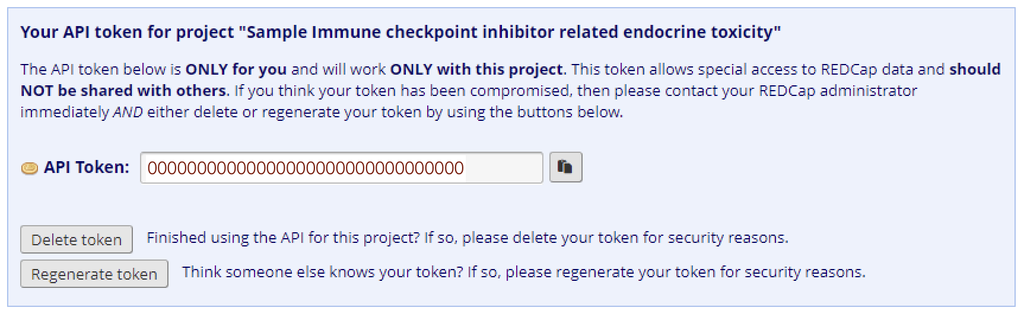

### Using an Environment Variable for API Token in R

You can save your API keys into a “hidden” file containing code that runs when you start R. That file is called the “.Renviron”. It can be a bit of a pain to find this file. So the best option is to install the `usethis` package, which contains helper functions, including a function to find this file.

```r
install.packages("remotes")
remotes::install_cran("usethis")
```

When it comes to add packages to your copy of R, the `install_cran()` function in the remotes package is superior to the usual `install.packages()` function because it will first check to see if you already have the latest version before bothering to download and install.

After installing `usethis` you can access your “.Renviron” file by typing this in your console.

```r
usethis::edit_r_environ()
```

It will cause the file to open. Create a name for your API key (for example: `rcap_immuno_key`) and add a line like this to your .Renviron file:

```
rcap_immuno_key="your_api_token_here"
```

After adding the line, remember to save the file and completely **restart R/RStudio.** Once R restarts, you can access the key like this:

```r
api_token <- Sys.getenv("rcap_immuno_key")
```

Once you have an API token, you can test whether it works using httr in R.

**Example: Checking Project Information**

```r
library(REDCapR)

# Define API URL and Token
url <- "https://redcap.petermac.org.au/api/"
token <- Sys.getenv("rcap_immuno_key")  # Load token securely

# Test API connection
formData <- list("token"=token,
    content='project',
    format='csv',
    returnFormat='json'
)
response <- httr::POST(url, body = formData, encode = "form")
result <- httr::content(response)

# Print project details
result
```

| project_id | project_title | creation_time | production_time | in_production | project_language | purpose | purpose_other | project_notes | custom_record_label | secondary_unique_field | is_longitudinal | has_repeating_instruments_or_events | surveys_enabled | scheduling_enabled | record_autonumbering_enabled | randomization_enabled | ddp_enabled | project_irb_number | project_grant_number | project_pi_firstname | project_pi_lastname | display_today_now_button | missing_data_codes | external_modules | bypass_branching_erase_field_prompt |
| --- | --- | --- | --- | --- | --- | --- | --- | --- | --- | --- | --- | --- | --- | --- | --- | --- | --- | --- | --- | --- | --- | --- | --- | --- | --- |
| 1840 | Sample Immune checkpoint inhibitor related endocrine toxicity | 2025-01-21 11:52:37 | 2025-01-21 15:55:23 | 1 | English | 1 | For a workshop | A database with dymmy data to be used for an R workshop titled Analysing REDCap data using R for Peter Mac employees | NA | NA | 1 | 1 | 1 | 0 | 0 | 0 | 0 | NA | NA | Anna | Galligan | 1 | NA | sticky_matrix_headers,data_dictionary_revisions,annotated_pdf,record_logging_link,data_driven_project_banner,project_autocomplete | 0 |

If the request is successful, you should see metadata about your REDCap project as shown above.

## Importing REDCap Data via API

Once you have set up your API token securely, you can use R to retrieve data directly from REDCap. The `REDCapR` package provides an interface to streamline API calls from R, making it easy to import records from a REDCap project.

### Reading REDCap Data

```r
requireNamespace("REDCapR")
# If this fails, run install.packages("REDCapR") or remotes::install_github(repo="OuhscBbmc/REDCapR")
```

#### Set project-wide values

There is some information that is specific to the REDCap project, as opposed to an individual operation. This includes: 1. the uniform resource identifier (uri) of the server 2. the token for the user’s project.

```r
library(REDCapR)

# Define API URL and Token
uri <- "https://redcap.petermac.org.au/api/"
token <- Sys.getenv("rcap_immuno_key")  # Load token securely
```

#### Read all records and fields

By default, the `redcap_read()` function retrieves the entire dataset from a REDCap project if no filtering parameters (such as records or fields) are specified.

```r
# Read the entire dataset
immuno_all_rows_all_fields <- redcap_read(redcap_uri = uri, token = token)$data

# print the top 6 rows
head(immuno_all_rows_all_fields)
```

| record_id | redcap_event_name | redcap_repeat_instrument | redcap_repeat_instance | ur | last_name | first_name | sex | dob | height | weight | bmi | coenrolled___1 | coenrolled___2 | coenrolled___3 | coenrolled___4 | clinical_trial | clinical_trial_description | medical_history___1 | medical_history___2 | medical_history___7 | medical_history___8 | medical_history___5 | medical_history___3 | medical_history___4 | medical_history___6 | medical_history___99 | medical_history_other | autoimmune_disease | autoimmune_disease_select___1 | … |
| --- | --- | --- | --- | --- | --- | --- | --- | --- | --- | --- | --- | --- | --- | --- | --- | --- | --- | --- | --- | --- | --- | --- | --- | --- | --- | --- | --- | --- | --- | --- |
| 1 | baseline_arm_1 | NA | NA | 2810493 | Jackson | Hannah | 2 | 1943-02-12 | 154 | 163 | 68.73 | 0 | 0 | 0 | 0 | NA | NA | 0 | 0 | 0 | 0 | 0 | 0 | 0 | 0 | 0 | NA | NA | 0 | … |
| 1 | baseline_arm_1 | prior_treatment | 1 | NA | NA | NA | NA | NA | NA | NA | NA | NA | NA | NA | NA | NA | NA | NA | NA | NA | NA | NA | NA | NA | NA | NA | NA | NA | NA | … |
| 2 | baseline_arm_1 | NA | NA | 6408685 | Howard | Samantha | 2 | 2008-01-29 | 181 | 97 | 29.61 | 0 | 0 | 0 | 0 | NA | NA | 0 | 0 | 0 | 0 | 0 | 0 | 0 | 0 | 0 | NA | NA | 0 | … |
| 3 | baseline_arm_1 | NA | NA | 9994173 | Martinez | Noah | 2 | 1940-11-06 | 199 | 123 | 31.06 | 0 | 0 | 0 | 0 | NA | NA | 0 | 0 | 0 | 0 | 0 | 0 | 0 | 0 | 0 | NA | NA | 0 | … |
| 3 | end_arm_1 | NA | NA | NA | NA | NA | NA | NA | NA | NA | NA | NA | NA | NA | NA | NA | NA | NA | NA | NA | NA | NA | NA | NA | NA | NA | NA | NA | NA | … |
| 3 | baseline_arm_1 | prior_treatment | 1 | NA | NA | NA | NA | NA | NA | NA | NA | NA | NA | NA | NA | NA | NA | NA | NA | NA | NA | NA | NA | NA | NA | NA | NA | NA | NA | … |

#### Read a subset of records

In many cases, you may only need data for a specific subset of records (e.g., certain patients). You can achieve this by specifying a list of record IDs in the records argument of `redcap_read()` as follows.

Pass an array (where each element is a record ID) to the records parameter:

```r
# Define the specific records to retrieve
selected_records <- c(985, 990, 1005)  # Replace with actual record IDs

# Read only the selected records
immuno_some_records <- redcap_read(
  redcap_uri = uri,
  token = token,
  records = selected_records
)$data

# print all rows
immuno_some_records
```

[output not shown]

#### Read a subset of fields

If you only need specific variables (e.g., record_id, dob, gender), you can specify a list of field names in the fields argument of `redcap_read()`.

```r
# Define the specific records to retrieve
selected_fields <- c("first_name", "dob", "mortality_date")  # Replace with actual record IDs

# Read only the selected records
immuno_some_fields <- redcap_read(
  redcap_uri = uri,
  token = token,
  fields = selected_fields
)$data

# print the top 6 rows
head(immuno_some_fields)
```

| record_id | redcap_event_name | redcap_repeat_instrument | redcap_repeat_instance | first_name | dob | mortality_date |
| --- | --- | --- | --- | --- | --- | --- |
| 1 | baseline_arm_1 | NA | NA | Hannah | 1943-02-12 | NA |
| 2 | baseline_arm_1 | NA | NA | Samantha | 2008-01-29 | NA |
| 3 | baseline_arm_1 | NA | NA | Noah | 1940-11-06 | NA |
| 3 | end_arm_1 | NA | NA | NA | NA | 2017-01-10 |
| 4 | baseline_arm_1 | NA | NA | Aiden | 1963-06-04 | NA |
| 4 | end_arm_1 | NA | NA | NA | NA | 2024-02-09 |

In all these cases, the data imported into R from REDCap is in its **raw format**. For example, a categorical variable like sex, which is expected to contain values such as “Male” or “Female,” may instead be represented as numeric codes (e.g., 1 for Male, 2 for Female). While these values can be manually recoded in R, doing so for large projects with multiple categorical variables can quickly become cumbersome and error-prone.

Furthermore, **complex study designs**—such as those used in *clinical trials, cohort studies, and observational research*—often involve **longitudinal data** or **repeating instruments**, adding another layer of complexity to data management.

- **Longitudinal data** is used when information is collected at *multiple time points or study events* (e.g., Baseline, Follow-up).

[figure not shown]

- **Repeating instruments** allow a single form to be completed *multiple times per participant* (e.g., recording multiple adverse events, medications, or hospital visits).

[figure not shown]

Handling these *structured data formats* in R requires additional steps for cleaning and organisation.

To address these challenges, the `REDCapTidieR` package extends the functionality of `REDCapR`, making it easier to analyse complex REDCap datasets.

#### Reading all REDCap data

Unlike `REDCapR`, which returns a single large dataframe, `REDCapTidieR` automatically structures and organises the data by breaking it into separate tibbles, each representing a different REDCap instrument. This makes it easier to work with studies involving multiple forms and events.

Before using `REDCapTidieR`, ensure it is installed along with its dependencies:

```r
# If this fails, run install.packages("REDCapTidieR") or
# devtools::install_github("CHOP-CGTInformatics/REDCapTidieR")
requireNamespace("REDCapTidieR")
```

To import the entire dataset while maintaining **structured tables** (or *supertibble*), use `read_redcap()`:

```r
# Load required packages
library(REDCapTidieR)

# Read entire REDCap project data
immuno <- read_redcap(redcap_uri = uri, token = token, raw_or_label = "raw")
```

```r
# print the structure of imported data
str(immuno, max.level = 2)
```

```
suprtbl [15 × 11] (S3: redcap_supertbl/tbl_df/tbl/data.frame)
 $ redcap_form_name : chr [1:15] "demographics" "melanoma_data" "adjuvant_therapy" "prior_treatment" ...
 $ redcap_form_label: chr [1:15] "Demographics" "Melanoma Data" "Adjuvant Therapy" "Systemic Therapy for Advanced Disease" ...
 $ redcap_data      :List of 15
 $ redcap_metadata  :List of 15
 $ redcap_events    :List of 15
 $ structure        : chr [1:15] "nonrepeating" "nonrepeating" "repeating" "repeating" ...
 $ data_rows        : int [1:15] 498 498 288 765 498 231 144 177 144 441 ...
 $ data_cols        : int [1:15] 38 26 61 177 22 67 41 8 128 47 ...
 $ data_size        : 'lobstr_bytes' num [1:15] 181.33 kB 130.62 kB 117.23 kB   1.10 MB  97.36 kB ...
 $ data_na_pct      : 'formattable' num [1:15]  13%  22%  82%  41%  62% ...
  ..- attr(*, "formattable")=List of 4
 $ form_complete_pct: 'formattable' num [1:15]  74%  74%  97%  96%  34% ...
  ..- attr(*, "formattable")=List of 4
```

# Exploring the Data

The supertibble object can be viewed with the [RStudio Data Viewer](https://cloud.r-project.org/web/packages/REDCapTidieR/vignettes/glossary.html#data-viewer). You can click on the table icon in the Environment tab to view of the supertibble in the data viewer. At a glance you see an overview of the instruments in the REDCap project.

[figure not shown]

Data Viewer showing the `immuno` supertibble

You can drill down into individual tables in the `redcap_data` and `redcap_metadata` columns. Note that in the `demographics` data tibble, each row represents a patient, identified by their `record_id`.

[figure not shown]

Data Viewer showing the `demographics` data tibble

In the `pet_imaging` data tibble, each row represents a PET scan information of a specific patient. Each row is identified by the combination of `record_id` and `redcap_form_instance`. This difference in granularity is because `pet_imaging` is a **repeating** instrument whereas `demographics` is a **nonrepeating** instrument.

[figure not shown]

Data Viewer showing the `pet_imaging` data tibble

You can also explore the metadata tibbles in the `redcap_metadata` column to find out about field labels, field types, and other field attributes.

[figure not shown]

Data Viewer showing the `demographics` metadata tibble

## Extracting data tibbles from the supertibble

`REDCapTidieR` provides three different functions to extract data tibbles from a supertibble.

### Binding data tibbles into the environment

The `bind_tibbles()` function takes a supertibble and binds its data tibbles directly into the global environment. When you use `bind_tibbles()` while working interactively in the RStudio IDE, you will see data tibbles appear in the Environment pane.

```r
immuno |> bind_tibbles()
```

[figure not shown]

Demonstration of the `bind_tibbles` function

By default, `bind_tibbles()` extracts all data tibbles from the supertibble. With the `tbls` argument you can specify a subset of data tibbles that should be extracted.

### Extracting a list of data tibbles

The `extract_tibbles()` function takes a supertibble and returns a named list of data tibbles. The default is to extract all data tibbles. We use `str` here to show the structure of the list returned by `extract_tibbles()`.

```r
immuno_instrument_list <- immuno |>
  extract_tibbles()

immuno_instrument_list |>
  str(max.level = 1)
```

```
List of 15
 $ demographics                                     : tibble [498 × 38] (S3: tbl_df/tbl/data.frame)
 $ melanoma_data                                    : tibble [498 × 26] (S3: tbl_df/tbl/data.frame)
 $ adjuvant_therapy                                 : tibble [288 × 61] (S3: tbl_df/tbl/data.frame)
 $ prior_treatment                                  : tibble [765 × 177] (S3: tbl_df/tbl/data.frame)
 $ melanoma_cns_metastases                          : tibble [498 × 22] (S3: tbl_df/tbl/data.frame)
 $ adverse_events                                   : tibble [231 × 67] (S3: tbl_df/tbl/data.frame)
 $ baseline_visit                                   : tibble [144 × 41] (S3: tbl_df/tbl/data.frame)
 $ checkpoint_inhibitor_treatment                   : tibble [177 × 8] (S3: tbl_df/tbl/data.frame)
 $ immune_related_adverse_events_iraes              : tibble [144 × 128] (S3: tbl_df/tbl/data.frame)
 $ pathology                                        : tibble [441 × 47] (S3: tbl_df/tbl/data.frame)
 $ ctmri_imaging                                    : tibble [332 × 12] (S3: tbl_df/tbl/data.frame)
 $ pet_imaging                                      : tibble [35 × 112] (S3: tbl_df/tbl/data.frame)
 $ ppi_and_antibiotic_use_during_treatment_with_cpis: tibble [23 × 7] (S3: tbl_df/tbl/data.frame)
 $ response_data                                    : tibble [144 × 23] (S3: tbl_df/tbl/data.frame)
 $ mortality_data                                   : tibble [381 × 10] (S3: tbl_df/tbl/data.frame)
```

## Adding variable labels with the labelled package

`REDCapTidieR` package allows you to attach labels to variables in the supertibble. Variable labels can make data exploration easier.

```r
immuno |>
  make_labelled() |>
  bind_tibbles()
```

The `make_labelled()` function takes a supertibble and returns a supertibble with variable labels applied to the variables of the supertibble as well as to the variables of all data and metadata tibbles in the `redcap_data` and `redcap_metadata` columns of the supertibble.

The RStudio Data Viewer shows variable labels below variable names.

[figure not shown]

Data Viewer showing part of a labelled supertibble

You can use the `labelled::look_for()` function to explore the variable labels of a tibble.

```r
labelled::look_for(mortality_data)
```

| pos | variable | label | col_type | missing | levels | value_labels |
| --- | --- | --- | --- | --- | --- | --- |
| 1 | record_id | Record ID | dbl | 0 | NULL | NULL |
| 2 | redcap_event | REDCap Event | chr | 0 | NULL | NULL |
| 3 | mortality | Has participant deceased? | dbl | 14 | NULL | NULL |
| 4 | mortality_date | Date of last follow up or death | date | 10 | NULL | NULL |
| 5 | ongoing_survelliance | Ongoing melanoma imaging surveillance? | dbl | 71 | NULL | NULL |
| 6 | date_last_scan | Date of last scan | date | 113 | NULL | NULL |
| 7 | mortality_treatment_time | Time since first treatment dose (months) | dbl | 60 | NULL | NULL |
| 8 | mortality_cause | Cause of Death | dbl | 156 | NULL | NULL |
| 9 | other_cause_death | Cause of death if not melanoma | lgl | 381 | NULL | NULL |
| 10 | form_status_complete | REDCap Instrument Completed? | dbl | 0 | NULL | NULL |

These labels are the REDCap **field labels** that prompt data entry in the REDCap instrument. `REDCapTidieR` places them into the `field_label` variable of the instrument’s metadata tibble. Below you can see that the field labels of the REDCap instrument for `mortality_data` are the same as the labels above.

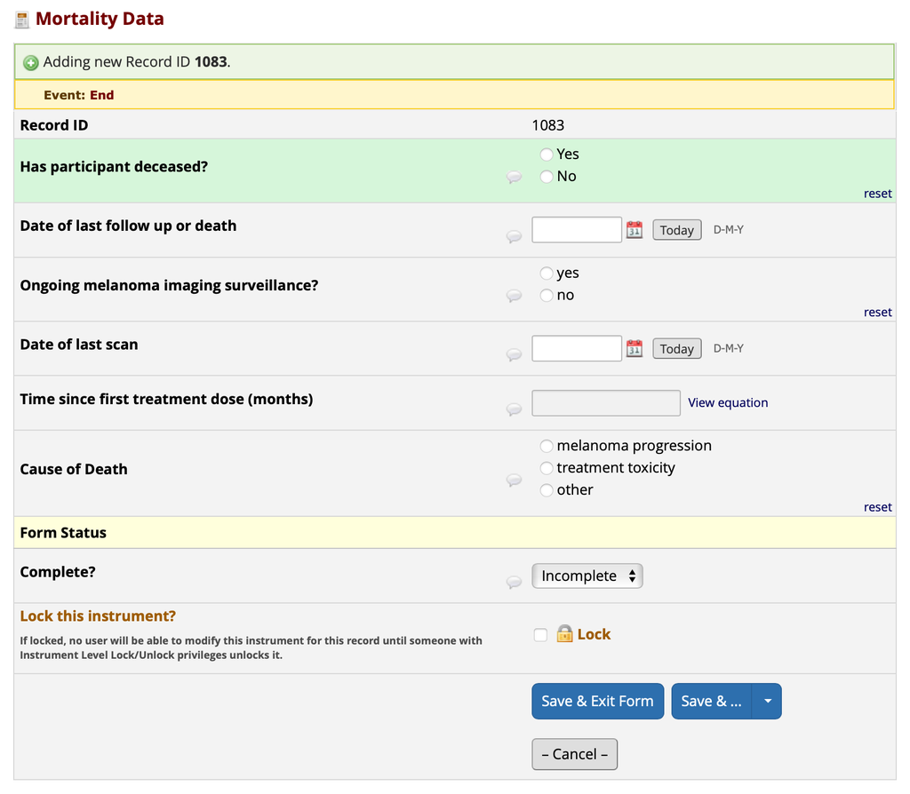

REDCap data entry view of the `mortality_data` instrument

In the `demographics` instrument, a label has a trailing colon `:` (check the label of `autoimmune_disease_select___9` variable below). This won’t look good as a variable label so let’s remove it.

```r
labelled::look_for(demographics)
```

| pos | variable | label | col_type | missing | levels | value_labels |
| --- | --- | --- | --- | --- | --- | --- |
| 1 | record_id | Record ID | dbl | 0 | NULL | NULL |
| 2 | redcap_event | REDCap Event | chr | 0 | NULL | NULL |
| 3 | ur | UR Number | dbl | 8 | NULL | NULL |
| 4 | last_name | Last Name | chr | 8 | NULL | NULL |
| 5 | first_name | First Name | chr | 8 | NULL | NULL |
| 6 | sex | Gender | dbl | 8 | NULL | NULL |
| 7 | dob | Date of Birth | date | 8 | NULL | NULL |
| 8 | height | Height | dbl | 8 | NULL | NULL |
| 9 | weight | Weight | dbl | 8 | NULL | NULL |
| 10 | bmi | BMI | dbl | 8 | NULL | NULL |
| 11 | coenrolled___1 | Other Studies Enrolled In: MetaMel | dbl | 0 | NULL | NULL |
| 12 | coenrolled___2 | Other Studies Enrolled In: Micromac | dbl | 0 | NULL | NULL |
| 13 | coenrolled___3 | Other Studies Enrolled In: MRV | dbl | 0 | NULL | NULL |
| 14 | coenrolled___4 | Other Studies Enrolled In: SUMMA | dbl | 0 | NULL | NULL |
| 15 | clinical_trial | Participating in a Clinical Trial | dbl | 113 | NULL | NULL |
| 16 | clinical_trial_description | Describe Trial(s) | chr | 401 | NULL | NULL |
| 17 | medical_history___1 | Medical History: Chronic kidney disease | dbl | 0 | NULL | NULL |
| 18 | medical_history___2 | Medical History: Diabetes | dbl | 0 | NULL | NULL |
| 19 | medical_history___7 | Medical History: Diabetes - Type 1 | dbl | 0 | NULL | NULL |
| 20 | medical_history___8 | Medical History: Diabetes - Type 2 | dbl | 0 | NULL | NULL |
| 21 | medical_history___5 | Medical History: GN | dbl | 0 | NULL | NULL |
| 22 | medical_history___3 | Medical History: Hypertension | dbl | 0 | NULL | NULL |
| 23 | medical_history___4 | Medical History: Ischaemic heart disease | dbl | 0 | NULL | NULL |
| 24 | medical_history___6 | Medical History: Vasculitis | dbl | 0 | NULL | NULL |
| 25 | medical_history___99 | Medical History: Other | dbl | 0 | NULL | NULL |
| 26 | medical_history_other | Medical History Other Unknown | chr | 415 | NULL | NULL |
| 27 | autoimmune_disease | History of Idiopathic Autoimmune Disease | dbl | 102 | NULL | NULL |
| 28 | autoimmune_disease_select___1 | Select Autoimmune Disease(s): Connective tissue disease | dbl | 0 | NULL | NULL |
| 29 | autoimmune_disease_select___2 | Select Autoimmune Disease(s): Inflammatory arthritis | dbl | 0 | NULL | NULL |
| 30 | autoimmune_disease_select___3 | Select Autoimmune Disease(s): Inflammatory bowel disease | dbl | 0 | NULL | NULL |
| 31 | autoimmune_disease_select___4 | Select Autoimmune Disease(s): Interstitial lung disease | dbl | 0 | NULL | NULL |
| 32 | autoimmune_disease_select___5 | Select Autoimmune Disease(s): Multiple sclerosis | dbl | 0 | NULL | NULL |
| 33 | autoimmune_disease_select___6 | Select Autoimmune Disease(s): Sarcoidosis | dbl | 0 | NULL | NULL |
| 34 | autoimmune_disease_select___9 | Select Autoimmune Disease(s): Other, specify: | dbl | 0 | NULL | NULL |
| 35 | autoimmune_disease_other | Describe Autoimmune Disease | lgl | 498 | NULL | NULL |
| 36 | rheumatoid_arthritis | Rheumatoid arthritis | lgl | 498 | NULL | NULL |
| 37 | smoking | Smoking History | dbl | 100 | NULL | NULL |
| 38 | form_status_complete | REDCap Instrument Completed? | dbl | 0 | NULL | NULL |

The `make_labelled()` function has a `format_labels` argument that you can use to preprocess labels before applying them to variables.

```r
immuno |>
  make_labelled(format_labels = ~ gsub(":", "", .)) |>
  bind_tibbles()

labelled::look_for(demographics, "autoimmune")
```

| pos | variable | label | col_type | missing | levels | value_labels |
| --- | --- | --- | --- | --- | --- | --- |
| 27 | autoimmune_disease | History of Idiopathic Autoimmune Disease | dbl | 102 | NULL | NULL |
| 28 | autoimmune_disease_select___1 | Select Autoimmune Disease(s) Connective tissue disease | dbl | 0 | NULL | NULL |
| 29 | autoimmune_disease_select___2 | Select Autoimmune Disease(s) Inflammatory arthritis | dbl | 0 | NULL | NULL |
| 30 | autoimmune_disease_select___3 | Select Autoimmune Disease(s) Inflammatory bowel disease | dbl | 0 | NULL | NULL |
| 31 | autoimmune_disease_select___4 | Select Autoimmune Disease(s) Interstitial lung disease | dbl | 0 | NULL | NULL |
| 32 | autoimmune_disease_select___5 | Select Autoimmune Disease(s) Multiple sclerosis | dbl | 0 | NULL | NULL |
| 33 | autoimmune_disease_select___6 | Select Autoimmune Disease(s) Sarcoidosis | dbl | 0 | NULL | NULL |
| 34 | autoimmune_disease_select___9 | Select Autoimmune Disease(s) Other, specify | dbl | 0 | NULL | NULL |
| 35 | autoimmune_disease_other | Describe Autoimmune Disease | lgl | 498 | NULL | NULL |

This remove all colons in labels.

To removing trailing `:` characters from a field label `REDCapTidieR` provides a format helper function that you can pass to the `format_labels` argument:

```r
fmt_strip_trailing_colon("Select Autoimmune Disease(s) Other, specify:")
```

```
[1] "Select Autoimmune Disease(s) Other, specify"
```

To find out about other helpers included with REDCapTidieR, see `` ?`format-helpers` ``.

The `format_labels` argument will also accept multiple functions in a vector or list. You can pass any function that takes a character vector and returns a modified character vector to `format_labels`. In the following example, we remove the trailing colon with `fmt_strip_trailing_colon()` and then make the labels lower case with `base::tolower()`.

```r
immuno |>
  make_labelled(
    format_labels = c(
      fmt_strip_trailing_colon,
      base::tolower
    )
  ) |>
  bind_tibbles()

labelled::look_for(demographics)
```

| pos | variable | label | col_type | missing | levels | value_labels |
| --- | --- | --- | --- | --- | --- | --- |
| 1 | record_id | record id | dbl | 0 | NULL | NULL |
| 2 | redcap_event | redcap event | chr | 0 | NULL | NULL |
| 3 | ur | ur number | dbl | 8 | NULL | NULL |
| 4 | last_name | last name | chr | 8 | NULL | NULL |
| 5 | first_name | first name | chr | 8 | NULL | NULL |
| 6 | sex | gender | dbl | 8 | NULL | NULL |
| 7 | dob | date of birth | date | 8 | NULL | NULL |
| 8 | height | height | dbl | 8 | NULL | NULL |
| 9 | weight | weight | dbl | 8 | NULL | NULL |
| 10 | bmi | bmi | dbl | 8 | NULL | NULL |
| 11 | coenrolled___1 | other studies enrolled in: metamel | dbl | 0 | NULL | NULL |
| 12 | coenrolled___2 | other studies enrolled in: micromac | dbl | 0 | NULL | NULL |
| 13 | coenrolled___3 | other studies enrolled in: mrv | dbl | 0 | NULL | NULL |
| 14 | coenrolled___4 | other studies enrolled in: summa | dbl | 0 | NULL | NULL |
| 15 | clinical_trial | participating in a clinical trial | dbl | 113 | NULL | NULL |
| 16 | clinical_trial_description | describe trial(s) | chr | 401 | NULL | NULL |
| 17 | medical_history___1 | medical history: chronic kidney disease | dbl | 0 | NULL | NULL |
| 18 | medical_history___2 | medical history: diabetes | dbl | 0 | NULL | NULL |
| 19 | medical_history___7 | medical history: diabetes - type 1 | dbl | 0 | NULL | NULL |
| 20 | medical_history___8 | medical history: diabetes - type 2 | dbl | 0 | NULL | NULL |
| 21 | medical_history___5 | medical history: gn | dbl | 0 | NULL | NULL |
| 22 | medical_history___3 | medical history: hypertension | dbl | 0 | NULL | NULL |
| 23 | medical_history___4 | medical history: ischaemic heart disease | dbl | 0 | NULL | NULL |
| 24 | medical_history___6 | medical history: vasculitis | dbl | 0 | NULL | NULL |
| 25 | medical_history___99 | medical history: other | dbl | 0 | NULL | NULL |
| 26 | medical_history_other | medical history other unknown | chr | 415 | NULL | NULL |
| 27 | autoimmune_disease | history of idiopathic autoimmune disease | dbl | 102 | NULL | NULL |
| 28 | autoimmune_disease_select___1 | select autoimmune disease(s): connective tissue disease | dbl | 0 | NULL | NULL |
| 29 | autoimmune_disease_select___2 | select autoimmune disease(s): inflammatory arthritis | dbl | 0 | NULL | NULL |
| 30 | autoimmune_disease_select___3 | select autoimmune disease(s): inflammatory bowel disease | dbl | 0 | NULL | NULL |
| 31 | autoimmune_disease_select___4 | select autoimmune disease(s): interstitial lung disease | dbl | 0 | NULL | NULL |
| 32 | autoimmune_disease_select___5 | select autoimmune disease(s): multiple sclerosis | dbl | 0 | NULL | NULL |
| 33 | autoimmune_disease_select___6 | select autoimmune disease(s): sarcoidosis | dbl | 0 | NULL | NULL |
| 34 | autoimmune_disease_select___9 | select autoimmune disease(s): other, specify | dbl | 0 | NULL | NULL |
| 35 | autoimmune_disease_other | describe autoimmune disease | lgl | 498 | NULL | NULL |
| 36 | rheumatoid_arthritis | rheumatoid arthritis | lgl | 498 | NULL | NULL |
| 37 | smoking | smoking history | dbl | 100 | NULL | NULL |
| 38 | form_status_complete | redcap instrument completed? | dbl | 0 | NULL | NULL |

## Renaming column names using labels

Some columns associated with **checkbox fields** in REDCap forms often have less intuitive names. For example, in the `melanoma_data` instrument, the melanoma type columns are named as `mel_type___1`, `mel_type___2`, `mel_type___3`, etc. These names correspond to different melanoma subtypes but are not easily interpretable.

To improve readability, these columns can be renamed using their corresponding labels, making the dataset more intuitive for analysis. The following function automates this renaming process by extracting variable labels and applying them to the column names.

```r
# This function rename checkbox columns using the labels
rename_checkbox_columns <- function(instrument, column_name_prefix) {
  # List of column names to rename
  col_names_to_rename <- labelled::look_for(instrument, column_name_prefix)$variable
  # New names for the selected columns
  new_names <- labelled::look_for(instrument, column_name_prefix)$label
  new_names <- str_replace_all(new_names, " ", "_")
  new_names <- str_replace_all(new_names, ":", "")
  # Rename the columns
  names(instrument)[names(instrument) %in% col_names_to_rename] <- new_names
  return(instrument)
}
```

```r
melanoma_data <- rename_checkbox_columns(melanoma_data, "mel_type___")
head(melanoma_data)
```

| record_id | redcap_event | melanoma_type_cutaneous | melanoma_type_mucosal | melanoma_type_acral | melanoma_type_uveal | melanoma_type_unknown_primary | melanoma_type_pathology_not_available | mel_type_cutaneous | mel_mutation___1 | mel_mutation___2 | mel_mutation___3 | mel_mutation___4 | mel_mutation___5 | mel_mutation___9 | mel_mutation_braf | mel_mutation_nras | mel_mutation_kit | mel_mutation_other | mel_first_date | mel_first_stage | resct1stdiag | mel_date_diag | stage_diagnosis | dt_advanced_dis | form_status_complete |
| --- | --- | --- | --- | --- | --- | --- | --- | --- | --- | --- | --- | --- | --- | --- | --- | --- | --- | --- | --- | --- | --- | --- | --- | --- | --- |
| 1 | baseline | 0 | 0 | 0 | 0 | 0 | 0 | NA | 0 | 0 | 0 | 0 | 0 | 0 | NA | NA | NA | NA | NA | NA | NA | NA | NA | NA | 0 |
| 2 | baseline | 0 | 0 | 0 | 0 | 0 | 0 | NA | 0 | 0 | 0 | 0 | 0 | 0 | NA | NA | NA | NA | NA | NA | NA | NA | NA | NA | 0 |
| 3 | baseline | 0 | 0 | 0 | 0 | 0 | 0 | NA | 0 | 0 | 0 | 0 | 0 | 0 | NA | NA | NA | NA | NA | NA | NA | NA | NA | NA | 0 |
| 4 | baseline | 0 | 0 | 0 | 0 | 0 | 0 | NA | 0 | 0 | 0 | 0 | 0 | 0 | NA | NA | NA | NA | NA | NA | NA | NA | NA | NA | 0 |
| 5 | baseline | 0 | 0 | 0 | 0 | 0 | 0 | 2 | 0 | 0 | 0 | 0 | 0 | 0 | V600M | NA | NA | NA | 2015-09-01 | 2 | 1 | 2016-03-10 | 1 | 27/10/16 | 0 |
| 6 | baseline | 0 | 0 | 0 | 0 | 0 | 0 | NA | 0 | 0 | 0 | 0 | 0 | 0 | NA | NA | NA | NA | NA | NA | NA | NA | NA | NA | 0 |

## Viewing the Data

This section demonstrates different ways to get to know the `immuno` dataset and its instruments.

When the name of the object is typed, the first few lines along with some information, such as the number of rows are displayed:

```r
immuno
```

Since this is a large dataset, the output is not shown here. But you can try executing the above code.

To view any column displayed above in the `immuno` object, you can specify the column number within `[[]]` or column name followed by `$`.

- For example to view column 1:

```r
immuno[[1]]
```

```
 [1] "demographics"
 [2] "melanoma_data"
 [3] "adjuvant_therapy"
 [4] "prior_treatment"
 [5] "melanoma_cns_metastases"
 [6] "adverse_events"
 [7] "baseline_visit"
 [8] "checkpoint_inhibitor_treatment"
 [9] "immune_related_adverse_events_iraes"
[10] "pathology"
[11] "ctmri_imaging"
[12] "pet_imaging"
[13] "ppi_and_antibiotic_use_during_treatment_with_cpis"
[14] "response_data"
[15] "mortality_data"
```

- For example to view `redcap_form_name` column:

```r
immuno$redcap_form_name
```

```
 [1] "demographics"
 [2] "melanoma_data"
 [3] "adjuvant_therapy"
 [4] "prior_treatment"
 [5] "melanoma_cns_metastases"
 [6] "adverse_events"
 [7] "baseline_visit"
 [8] "checkpoint_inhibitor_treatment"
 [9] "immune_related_adverse_events_iraes"
[10] "pathology"
[11] "ctmri_imaging"
[12] "pet_imaging"
[13] "ppi_and_antibiotic_use_during_treatment_with_cpis"
[14] "response_data"
[15] "mortality_data"
```

A similar method can be used to access the patient data in all instruments using the `redcap_data` column or the 3rd column in this case. However, this displays patient data of all the instruments one after the other, making it difficult to read. A better way is to view a single instrument as follows.

For example, to view the `mortality_data` instrument, we can access the redcap_data column first (i.e., `immuno$redcap_data` or `immuno[[3]]`) and then access the 15th instrument:

```r
head(immuno$redcap_data[[15]]) # same as immuno[[3]][[15]]
```

| record_id | redcap_event | mortality | mortality_date | ongoing_survelliance | date_last_scan | mortality_treatment_time | mortality_cause | other_cause_death | form_status_complete |
| --- | --- | --- | --- | --- | --- | --- | --- | --- | --- |
| 3 | end | 1 | 2017-01-10 | 2 | 2016-10-24 | 4.7 | NA | NA | 2 |
| 4 | end | 0 | 2024-02-09 | 2 | 2023-06-29 | NA | NA | NA | 2 |
| 7 | end | 0 | 2024-10-15 | 2 | 2021-09-01 | NA | NA | NA | 2 |
| 8 | end | 0 | 2024-09-20 | 1 | 2024-09-09 | NA | NA | NA | 2 |
| 12 | end | 1 | 2016-11-18 | NA | 2016-01-04 | NA | 1 | NA | 2 |
| 16 | end | 0 | 2024-04-26 | 1 | 2023-07-14 | NA | 1 | NA | 2 |

The `dim()` function prints the dimensions (rows x columns):

```r
dim(immuno)
```

```
[1] 15 11
```

```r
dim(immuno$redcap_data[[15]])
```

```
[1] 381  10
```

This information is available at the environment pane in the top right panel as the number of observations (rows) and variables (columns).

The `nrow()` function prints the number of rows while `ncol()` prints the number of columns:

```r
nrow(immuno$redcap_data[[15]])
```

```
[1] 381
```

```r
ncol(immuno$redcap_data[[15]])
```

```
[1] 10
```

The `View()` function gives a spreadsheet-like view of the data frame:

```r
View(immuno)
```

By clicking the object on the environment tab also gives a spreadsheet-like view of the object:

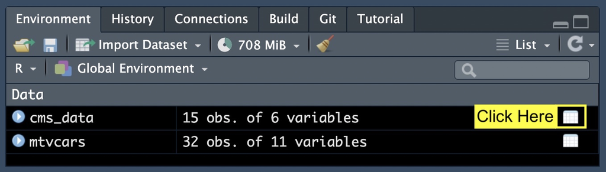

The `head()` function prints the top 6 rows of a data frame:

```r
head(immuno$redcap_data[[15]])
```

| record_id | redcap_event | mortality | mortality_date | ongoing_survelliance | date_last_scan | mortality_treatment_time | mortality_cause | other_cause_death | form_status_complete |
| --- | --- | --- | --- | --- | --- | --- | --- | --- | --- |
| 3 | end | 1 | 2017-01-10 | 2 | 2016-10-24 | 4.7 | NA | NA | 2 |
| 4 | end | 0 | 2024-02-09 | 2 | 2023-06-29 | NA | NA | NA | 2 |
| 7 | end | 0 | 2024-10-15 | 2 | 2021-09-01 | NA | NA | NA | 2 |
| 8 | end | 0 | 2024-09-20 | 1 | 2024-09-09 | NA | NA | NA | 2 |
| 12 | end | 1 | 2016-11-18 | NA | 2016-01-04 | NA | 1 | NA | 2 |
| 16 | end | 0 | 2024-04-26 | 1 | 2023-07-14 | NA | 1 | NA | 2 |

Similarly, the `tail()` function prints the bottom 6 rows of the data frame:

```r
tail(immuno$redcap_data[[15]])
```

| record_id | redcap_event | mortality | mortality_date | ongoing_survelliance | date_last_scan | mortality_treatment_time | mortality_cause | other_cause_death | form_status_complete |
| --- | --- | --- | --- | --- | --- | --- | --- | --- | --- |
| 492 | end | 1 | 2017-10-18 | NA | NA | 6.8 | 1 | NA | 2 |
| 493 | end | 1 | 2024-06-26 | 2 | NA | 32.5 | 1 | NA | 2 |
| 494 | end | 1 | 2016-02-12 | 2 | NA | 6.1 | 1 | NA | 2 |
| 496 | end | 1 | 2018-06-28 | 2 | NA | NA | 1 | NA | 2 |
| 497 | end | 1 | 2016-08-04 | 2 | NA | 1.1 | 1 | NA | 2 |
| 499 | end | NA | 2018-10-09 | NA | NA | NA | NA | NA | 2 |

The `colnames()` function displays all the column names:

```r
colnames(immuno$redcap_data[[15]])
```

```
 [1] "record_id"                "redcap_event"
 [3] "mortality"                "mortality_date"
 [5] "ongoing_survelliance"     "date_last_scan"
 [7] "mortality_treatment_time" "mortality_cause"
 [9] "other_cause_death"        "form_status_complete"
```

The `$` symbol allows access to individual columns. To display `mortality_date` column:

```r
head(immuno$redcap_data[[15]]$mortality_date)
```

```
[1] "2017-01-10" "2024-02-09" "2024-10-15" "2024-09-20" "2016-11-18"
[6] "2024-04-26"
```

The `str()` function shows the structure of the data:

```r
str(immuno$redcap_data[[15]])
```

```
tibble [381 × 10] (S3: tbl_df/tbl/data.frame)
 $ record_id               : num [1:381] 3 4 7 8 12 16 23 24 28 29 ...
 $ redcap_event            : chr [1:381] "end" "end" "end" "end" ...
 $ mortality               : num [1:381] 1 0 0 0 1 0 1 1 0 1 ...
 $ mortality_date          : Date[1:381], format: "2017-01-10" "2024-02-09" ...
 $ ongoing_survelliance    : num [1:381] 2 2 2 1 NA 1 NA 2 1 2 ...
 $ date_last_scan          : Date[1:381], format: "2016-10-24" "2023-06-29" ...
 $ mortality_treatment_time: num [1:381] 4.7 NA NA NA NA NA NA 17.2 80.4 9.7 ...
 $ mortality_cause         : num [1:381] NA NA NA NA 1 1 1 1 1 1 ...
 $ other_cause_death       : logi [1:381] NA NA NA NA NA NA ...
 $ form_status_complete    : num [1:381] 2 2 2 2 2 2 2 2 2 2 ...
```

The `glimpse()`function (dplyr package) displays a compact summary of the data frame, showing you key details such as the data types of each column, the first few values, and the total number of observations.

```r
glimpse(immuno$redcap_data[[15]])
```

```
Rows: 381
Columns: 10
$ record_id                <dbl> 3, 4, 7, 8, 12, 16, 23, 24, 28, 29, 31, 37, 3…
$ redcap_event             <chr> "end", "end", "end", "end", "end", "end", "en…
$ mortality                <dbl> 1, 0, 0, 0, 1, 0, 1, 1, 0, 1, 1, 1, 0, 0, 1, …
$ mortality_date           <date> 2017-01-10, 2024-02-09, 2024-10-15, 2024-09-…
$ ongoing_survelliance     <dbl> 2, 2, 2, 1, NA, 1, NA, 2, 1, 2, NA, 2, 1, 1, …
$ date_last_scan           <date> 2016-10-24, 2023-06-29, 2021-09-01, 2024-09-…
$ mortality_treatment_time <dbl> 4.7, NA, NA, NA, NA, NA, NA, 17.2, 80.4, 9.7,…
$ mortality_cause          <dbl> NA, NA, NA, NA, 1, 1, 1, 1, 1, 1, 1, 1, NA, N…
$ other_cause_death        <lgl> NA, NA, NA, NA, NA, NA, NA, NA, NA, NA, NA, N…
$ form_status_complete     <dbl> 2, 2, 2, 2, 2, 2, 2, 2, 2, 2, 2, 2, 2, 2, 2, …
```

The `summary()` function generates summary statistics:

```r
summary(immuno$redcap_data[[15]])
```

```
   record_id     redcap_event         mortality      mortality_date
 Min.   :  3.0   Length:381         Min.   :0.0000   Min.   :2013-11-15
 1st Qu.:150.0   Class :character   1st Qu.:0.0000   1st Qu.:2018-08-02
 Median :270.0   Mode  :character   Median :1.0000   Median :2021-07-20
 Mean   :265.2                      Mean   :0.5313   Mean   :2021-04-11
 3rd Qu.:382.0                      3rd Qu.:1.0000   3rd Qu.:2024-02-15
 Max.   :499.0                      Max.   :1.0000   Max.   :2024-10-15
                                    NA's   :14       NA's   :10
 ongoing_survelliance date_last_scan       mortality_treatment_time
 Min.   :1.000        Min.   :0624-01-02   Min.   :  0.10
 1st Qu.:1.000        1st Qu.:2020-05-30   1st Qu.: 11.70
 Median :2.000        Median :2023-07-06   Median : 33.40
 Mean   :1.597        Mean   :2016-11-19   Mean   : 40.41
 3rd Qu.:2.000        3rd Qu.:2024-02-09   3rd Qu.: 62.30
 Max.   :2.000        Max.   :2028-07-06   Max.   :131.50
 NA's   :71           NA's   :113          NA's   :60
 mortality_cause other_cause_death form_status_complete
 Min.   :1.000   Mode:logical      Min.   :0.000
 1st Qu.:1.000   NA's:381          1st Qu.:2.000
 Median :1.000                     Median :2.000
 Mean   :1.173                     Mean   :1.995
 3rd Qu.:1.000                     3rd Qu.:2.000
 Max.   :3.000                     Max.   :2.000
 NA's   :156
```

A statistical overview can be obtained using the `skim()` function in skimr package:

```r
library(skimr)
skim(immuno$redcap_data[[15]])
```

Data summary

| Name | immuno$redcap_data[[15]] |
| --- | --- |
| Number of rows | 381 |
| Number of columns | 10 |
| _______________________ |  |
| Column type frequency: |  |
| character | 1 |
| Date | 2 |
| logical | 1 |
| numeric | 6 |
| ________________________ |  |
| Group variables | None |

**Variable type: character**

| skim_variable | n_missing | complete_rate | min | max | empty | n_unique | whitespace |
| --- | --- | --- | --- | --- | --- | --- | --- |
| redcap_event | 0 | 1 | 3 | 3 | 0 | 1 | 0 |

**Variable type: Date**

| skim_variable | n_missing | complete_rate | min | max | median | n_unique |
| --- | --- | --- | --- | --- | --- | --- |
| mortality_date | 10 | 0.97 | 2013-11-15 | 2024-10-15 | 2021-07-20 | 293 |
| date_last_scan | 113 | 0.70 | 0624-01-02 | 2028-07-06 | 2023-07-06 | 218 |

**Variable type: logical**

| skim_variable | n_missing | complete_rate | mean | count |
| --- | --- | --- | --- | --- |
| other_cause_death | 381 | 0 | NaN | : |

**Variable type: numeric**

| skim_variable | n_missing | complete_rate | mean | sd | p0 | p25 | p50 | p75 | p100 | hist |
| --- | --- | --- | --- | --- | --- | --- | --- | --- | --- | --- |
| record_id | 0 | 1.00 | 265.17 | 134.35 | 3.0 | 150.0 | 270.0 | 382.0 | 499.0 | ▅▇▇▇▇ |
| mortality | 14 | 0.96 | 0.53 | 0.50 | 0.0 | 0.0 | 1.0 | 1.0 | 1.0 | ▇▁▁▁▇ |
| ongoing_survelliance | 71 | 0.81 | 1.60 | 0.49 | 1.0 | 1.0 | 2.0 | 2.0 | 2.0 | ▆▁▁▁▇ |
| mortality_treatment_time | 60 | 0.84 | 40.41 | 31.58 | 0.1 | 11.7 | 33.4 | 62.3 | 131.5 | ▇▅▃▂▁ |
| mortality_cause | 156 | 0.59 | 1.17 | 0.54 | 1.0 | 1.0 | 1.0 | 1.0 | 3.0 | ▇▁▁▁▁ |
| form_status_complete | 0 | 1.00 | 1.99 | 0.10 | 0.0 | 2.0 | 2.0 | 2.0 | 2.0 | ▁▁▁▁▇ |

## Writing Data to a File

Writing data to a file is a fundamental operation in programming and data analysis. It involves taking data from within a program or environment and storing it in a file on a disk for later use or sharing. This section explains the basics of writing a data file using the **readr** package.

The `write_csv()` and `write_tsv()` functions are part of the **readr** package, which is designed for writing delimited files like CSV (comma-separated values) and TSV (tab-separated values). These functions are used to write data frames into CSV and TSV files, respectively.

We first provide the variable name of the data frame followed by the file name (ideally including the full folder location).

To write a CSV file:

```r
# on Mac:
write_csv(cms_data, "~/Desktop/cms_data.csv")

# on Windows
write_csv(cms_data, "C:/Users/srajapaksa/Desktop/cms_data.csv")
```

To write a TSV file:

```r
# on Mac:
write_tsv(cms_data, "~/Desktop/cms_data.csv")

# on Windows
write_tsv(cms_data, "C:/Users/srajapaksa/Desktop/cms_data.csv")
```

## The Pipe Operator (`|>` or `%>%`)

The *pipe* operator (`|>`) is a commonly used feature of the tidyverse. It was originally defined in the (cleverly named) magrittr package, but is also included in the `dplyr`, tidyverse packages. The `|>` symbol can seem confusing and intimidating at first. However, once you understand the basic idea, it can become addicting!

We suggest you use a shortcut: `⌘` + `Shift` + `M` (Mac) or `Ctrl` + `Shift` + `M` (Windows/Linux).

The `|>` symbol is placed between a value on the left and a function on the right. The `|>` simply takes the value to the left and passes it to the function on the right as the first argument. It acts as a “pipe”. That’s it!

Suppose we have a variable, `x`.

```r
x <- 7
```

The following are the exact same.

```r
sqrt(x)
```

```
[1] 2.645751
```

```r
x |> sqrt()
```

```
[1] 2.645751
```

We’ll continue to use `|>` throughout this tutorial to show how useful it can be for chaining various data manipulation steps during an analysis.

### Chaining functions

R *chaining* allows you to streamline your data analysis workflow by sequentially applying multiple operations to your data using the pipe operator `|>`. We often need to perform several data manipulation or analysis operations in a sequence. Chaining allows you to apply these operations one after the other in a clear and concise manner.

Here’s a basic template for chaining operations using the pipe operator `|>`:

```r
result <- data |>
    operation1(...) |>
    operation2(...) |>
    operation3(...) |>
    ...
    operationN(...)
```

In this template:

- `data` represents the input data frame or object.
- `operation1`, `operation2`, …, `operationN` represent the functions or operations you want to apply sequentially to the data.For example: `select()`, `filter()` or `mutate()` functions.
- `...` represents any additional arguments or parameters that may be passed to each operation.

Each operation takes the output of the previous operation as its input, making it easy to chain multiple operations together. This improves the readability of your code by organising operations in a left-to-right fashion and it avoids creating intermediate variables to store the results of each operation.

# Data manipulation with `dplyr` functions

Common tasks in working with data include actions like filtering rows or columns, performing calculations, or adding new columns. This sort of operations is known as data manipulation. It is the process of cleaning, organising, and transforming raw data into a more structured and usable format for analysis.

In this workshop, we’ll guide you through the process of data manipulation in R, starting with the tidyverse. The tidyverse is a collection of packages that align with a data science philosophy developed by Hadley Wickham and the RStudio team. Many users find it to be a more intuitive way to grasp R concepts.

You’ll primarily use five key `dplyr` functions for data manipulations:

1. **`filter()`:** pick observations based on their values.
2. **`select()`:** pick variables by their names.
3. **`mutate()`:** create new variables using functions applied to existing variables.
4. **`summarise()`:** collapse multiple values into a single summary.
5. **`arrange()`:** reorder the rows based on specified criteria.

If you’ve already installed the tidyverse package (if not, you can do so by running the command: `install.packages("tidyverse")`), let’s proceed to load it into our R session first:

```r
library(tidyverse)
```

Next, load the pre-processed RDS Object:

```r
immuno_dataset <- readRDS("data/Sample_immuno_dataset.rds")
```

**RDS (R Data Serialisation)** files are used to save and load single R objects while preserving their structure, labels, and attributes. The *.rds* format is useful for storing dataframes, lists, models, and other complex objects. For convenience, the previously loaded REDCap dataset has been pre-processed and saved as an .rds file. This pre-processed version will be used throughout the remainder of the workshop.

### `filter()`

The `filter()` function takes logical expressions and returns the rows for which all are `TRUE`.

[figure not shown]

**Example 1:** Find all records from the `melanoma_data` data frame where the melanoma type is cutaneous.

```r
immuno_dataset$redcap_data$melanoma_data |>
  filter(melanoma_type == "cutaneous") |>
  head()
```

| record_id | redcap_event | melanoma_type | melanoma_molecular_mutation | mel_first_date | mel_first_stage | resct1stdiag | mel_date_diag | stage_diagnosis | dt_advanced_dis |
| --- | --- | --- | --- | --- | --- | --- | --- | --- | --- |
| 16 | baseline | cutaneous | nras | 2019-06-01 | Stage III | TRUE | 2017-01-01 | yes | 01062017 |
| 24 | baseline | cutaneous | wild_type | 2014-03-27 | Stage II | TRUE | 2015-01-01 | yes | 1/9/15 |
| 28 | baseline | cutaneous | braf | 2015-09-01 | Stage II | TRUE | 2016-03-10 | yes | 27/10/16 |
| 57 | baseline | cutaneous | nras | 2019-12-01 | Stage I | TRUE | 2020-07-09 | yes | 08/01/2021 |
| 58 | baseline | cutaneous | wild_type | 2013-10-01 | Stage I | TRUE | 2015-09-14 | yes | 6/3/17 |
| 60 | baseline | cutaneous | braf | 2017-03-01 | Stage III | TRUE | 2019-11-01 | no | 1/11/19 |

Here we are *sending* the `immuno_dataset$redcap_data$melanoma_data` data frame into the function `filter()` which tests each value in melanoma_type column for the value “cutaneous” and returns the rows where this condition is TRUE.

You can check the dimension (number of rows and number of columns) of the resulting data frame by using the `dim()` function as follows:

```r
immuno_dataset$redcap_data$melanoma_data |> filter(melanoma_type == "cutaneous") |> dim()
```

```
[1] 265  10
```

**Example 2:** Identify records in `mortality_data` where time since first treatment dose (`mortality_treatment_time`) exceeds 1 year. `mortality_treatment_time` is given in months.

```r
immuno_dataset$redcap_data$mortality_data |>
  filter(mortality_treatment_time > 12) |>
  head()
```

| record_id | redcap_event | mortality | mortality_date | ongoing_survelliance | date_last_scan | mortality_treatment_time | mortality_cause |
| --- | --- | --- | --- | --- | --- | --- | --- |
| 24 | end | TRUE | 2017-03-03 | no | NA | 17.2 | melanoma progression |
| 28 | end | FALSE | 2023-08-18 | yes | 2022-08-03 | 80.4 | melanoma progression |
| 31 | end | TRUE | 2017-11-09 | NA | NA | 54.3 | melanoma progression |
| 38 | end | FALSE | 2024-04-15 | yes | 2024-06-01 | 109.6 | NA |
| 43 | end | FALSE | 2024-06-12 | yes | 2024-06-13 | 61.9 | NA |
| 48 | end | FALSE | 2023-01-26 | yes | NA | 89.0 | NA |

We can use logical operators like and `&`, or `|` to combine multiple conditions as follows.

```r
immuno_dataset$redcap_data$mortality_data |>
  filter(mortality_cause == "melanoma progression" & mortality_date > as.Date("2023-01-01")) |>
  head()
```

| record_id | redcap_event | mortality | mortality_date | ongoing_survelliance | date_last_scan | mortality_treatment_time | mortality_cause |
| --- | --- | --- | --- | --- | --- | --- | --- |
| 16 | end | FALSE | 2024-04-26 | yes | 2023-07-14 | NA | melanoma progression |
| 28 | end | FALSE | 2023-08-18 | yes | 2022-08-03 | 80.4 | melanoma progression |
| 68 | end | FALSE | 2024-01-19 | yes | 2023-04-18 | 46.1 | melanoma progression |
| 72 | end | FALSE | 2024-03-21 | yes | 2024-03-15 | 53.6 | melanoma progression |
| 77 | end | FALSE | 2024-07-05 | yes | 2024-06-28 | 91.1 | melanoma progression |
| 87 | end | TRUE | 2024-01-28 | no | 2015-10-17 | 24.9 | melanoma progression |

```r
immuno_dataset$redcap_data$melanoma_data |>
  filter(melanoma_molecular_mutation == "braf" | melanoma_molecular_mutation == "braf") |>
  head()
```

| record_id | redcap_event | melanoma_type | melanoma_molecular_mutation | mel_first_date | mel_first_stage | resct1stdiag | mel_date_diag | stage_diagnosis | dt_advanced_dis |
| --- | --- | --- | --- | --- | --- | --- | --- | --- | --- |
| 28 | baseline | cutaneous | braf | 2015-09-01 | Stage II | TRUE | 2016-03-10 | yes | 27/10/16 |
| 60 | baseline | cutaneous | braf | 2017-03-01 | Stage III | TRUE | 2019-11-01 | no | 1/11/19 |
| 70 | baseline | cutaneous | braf | 2012-01-01 | Stage unknown as pathology unavailable | TRUE | 2017-08-18 | no | NA |
| 79 | baseline | cutaneous | braf | 2015-04-01 | Stage unknown as pathology unavailable | TRUE | 2018-12-01 | no | 1/12/18 |
| 80 | baseline | cutaneous | braf | 2013-01-01 | Stage I | TRUE | 2015-10-01 | yes | 8/10/15 |
| 85 | baseline | cutaneous | braf | 2012-07-01 | Stage II | TRUE | 2014-12-04 | no | 4/12/14 |

**Example 5:** Retrieve records where `mortality_cause` is due to “treatment toxicity” and `mortality_treatment_time` is greater than 4 months but less than or equal to 10 months.

```r
immuno_dataset$redcap_data$mortality_data |>
  filter(
    mortality_cause == "treatment toxicity" &
    mortality_treatment_time > 4 &
    mortality_treatment_time <= 10)
```

| record_id | redcap_event | mortality | mortality_date | ongoing_survelliance | date_last_scan | mortality_treatment_time | mortality_cause |
| --- | --- | --- | --- | --- | --- | --- | --- |
| 414 | end | TRUE | 2019-02-18 | no | 2019-01-31 | 7.0 | treatment toxicity |
| 429 | end | TRUE | 2020-04-22 | no | NA | 5.2 | treatment toxicity |

#### `%in%` helper

The `%in%` function is used to determine whether elements of one vector are present in another vector. It returns a logical vector indicating whether each element of the first vector is found in the second vector.

When we want to filter a subset of rows that may contain multiple different values, it’s more efficient to provide a vector of the values of interest instead of combining multiple OR commands.

**Example 6:** Retrieve records where `melanoma_type` is acral, cutaneous or muscosal.

```r
immuno_dataset$redcap_data$melanoma_data |>
  filter(melanoma_type %in% c("acral", "cutaneous",  "muscosal")) |>
  head()
```

| record_id | redcap_event | melanoma_type | melanoma_molecular_mutation | mel_first_date | mel_first_stage | resct1stdiag | mel_date_diag | stage_diagnosis | dt_advanced_dis |
| --- | --- | --- | --- | --- | --- | --- | --- | --- | --- |
| 16 | baseline | cutaneous | nras | 2019-06-01 | Stage III | TRUE | 2017-01-01 | yes | 01062017 |
| 24 | baseline | cutaneous | wild_type | 2014-03-27 | Stage II | TRUE | 2015-01-01 | yes | 1/9/15 |
| 28 | baseline | cutaneous | braf | 2015-09-01 | Stage II | TRUE | 2016-03-10 | yes | 27/10/16 |
| 44 | baseline | acral | NA | 2012-04-20 | Stage II | TRUE | 2016-03-30 | no | 30/3/16 |
| 57 | baseline | cutaneous | nras | 2019-12-01 | Stage I | TRUE | 2020-07-09 | yes | 08/01/2021 |
| 58 | baseline | cutaneous | wild_type | 2013-10-01 | Stage I | TRUE | 2015-09-14 | yes | 6/3/17 |

**Try It Yourself**

Find patients who have stage III or IV disease (`mel_first_stage` column) and the first recurrence (`mel_date_diag`) is after 2021-03-01.

*Hint: Use `melanoma_data` instrument*

**Solution**

```r
immuno_dataset$redcap_data$melanoma_data |>
  filter(
    mel_first_stage %in% c("Stage III", "Stage IV") &
    mel_date_diag > as.Date("2021-03-01"))
```

### `select()`

The `select()` function returns a subset of the variables or columns.

[figure not shown]

This function can accept column names (even without quotation marks) or the column position number starting from the left. Unlike in base R (we explore before), commands within the brackets in `select()` do not need to be concatenated using `c()`.

**Example 1:** Extract the record ID, Echo date (`ae_echo_date`) and MRI date (`ae_mri_date`) columns from `adverse_events` data frame.

```r
immuno_dataset$redcap_data$adverse_events |>
  select(record_id, ae_echo_date, ae_mri_date) |>
  filter(!is.na(ae_echo_date)) # filter non-missing values in ae_echo_date column
```

| record_id | ae_echo_date | ae_mri_date |
| --- | --- | --- |
| 104 | 2022-10-19 | 2022-09-27 |
| 104 | 2022-10-19 | 2022-09-27 |
| 104 | 2022-10-19 | 2022-09-27 |
| 104 | 2022-10-19 | 2022-09-27 |

Using column positions:

```r
immuno_dataset$redcap_data$adverse_events |>
  select(1, 23, 30) |>
  filter(!is.na(ae_echo_date)) # filter non-missing values in ae_echo_date column
```

| record_id | ae_echo_date | ae_mri_date |
| --- | --- | --- |
| 104 | 2022-10-19 | 2022-09-27 |
| 104 | 2022-10-19 | 2022-09-27 |
| 104 | 2022-10-19 | 2022-09-27 |
| 104 | 2022-10-19 | 2022-09-27 |

We can use the ‘-’ symbol to extract all columns except for specific ones:

```r
immuno_dataset$redcap_data$demographics |>
  select(-redcap_event, -ur, -sex, -dob, -height, -weight) |>
  head()
```

| record_id | last_name | first_name | bmi | other_studies_enrolled_in | medical_history | autoimmune_disease | select_autoimmune_diseases | smoking |
| --- | --- | --- | --- | --- | --- | --- | --- | --- |
| 1 | Jackson | Hannah | 68.73 | NA | NA | NA | NA | NA |
| 2 | Howard | Samantha | 29.61 | NA | NA | NA | NA | NA |
| 3 | Martinez | Noah | 31.06 | NA | NA | NA | NA | NA |
| 4 | Lewis | Aiden | 51.51 | NA | NA | NA | NA | NA |
| 5 | Jenkins | Connor | 20.28 | NA | NA | FALSE | NA | Past smoker |
| 6 | Allen | Claire | 28.06 | NA | NA | NA | NA | NA |

Or use a combination of column names and positions:

```r
immuno_dataset$redcap_data$demographics |>
  select(1, medical_history, 15) |>
  head()
```

| record_id | medical_history | smoking |
| --- | --- | --- |
| 1 | NA | NA |
| 2 | NA | NA |
| 3 | NA | NA |
| 4 | NA | NA |
| 5 | NA | Past smoker |
| 6 | NA | NA |

#### Useful helper functions

The select helper functions (check `?select_helpers`) are a set of convenience functions provided by the `dplyr` package. These functions offer shortcuts for selecting columns based on specific criteria or patterns, making it easier to work with data frames.

Some commonly used select helper functions include:

1. **`starts_with()`:** selects columns that start with a specified prefix.

```r
immuno_dataset$redcap_data$immune_related_adverse_events_iraes |>
  select(starts_with('liver')) |>
  head()
```

| liver_date | liver_cycle | liver_grade | liver_path | liver_histo | liver_radiol |
| --- | --- | --- | --- | --- | --- |
| NA | NA | NA | NA | NA | NA |
| NA | NA | NA | NA | NA | NA |
| NA | NA | NA | NA | NA | NA |
| NA | NA | NA | NA | NA | NA |
| NA | NA | NA | NA | NA | NA |
| NA | NA | NA | NA | NA | NA |

2. **`ends_with()`:** selects columns that end with a specified suffix.

```r
immuno_dataset$redcap_data$immune_related_adverse_events_iraes |>
  select(ends_with('date')) |>
  head()
```

| hypophysitis_date | thyroiditis_date | pancreatitis_date | skin_date | rheum_date | gastro_date | liver_date | renal_date | pulm_date | neuro_date |
| --- | --- | --- | --- | --- | --- | --- | --- | --- | --- |
| 2017-01-20 | NA | NA | 2016-09-21 | NA | NA | NA | NA | NA | NA |
| 2017-01-20 | NA | NA | 2016-09-21 | NA | NA | NA | NA | NA | NA |
| NA | NA | NA | NA | NA | NA | NA | NA | NA | NA |
| NA | NA | NA | NA | NA | NA | NA | NA | NA | NA |
| NA | NA | NA | NA | NA | NA | NA | NA | NA | NA |
| NA | NA | NA | NA | NA | NA | NA | NA | NA | NA |

3. **`contains()`:** selects columns that contain a specified substring.

```r
immuno_dataset$redcap_data$immune_related_adverse_events_iraes |>
  select(contains('skin')) |>
  head()
```

| skin_date | skin_cycle | characterise_skin/hair_irae | skin_grade | skin_histo |
| --- | --- | --- | --- | --- |
| 2016-09-21 | NA | bullous_pemphigoid | 3 | Consistent with a pemphigoid-type reaction, possibly drug-related or consistent with Bullous Pemphigoid. |
| 2016-09-21 | NA | bullous_pemphigoid | 3 | Consistent with a pemphigoid-type reaction, possibly drug-related or consistent with Bullous Pemphigoid. |
| NA | NA | NA | NA | NA |
| NA | NA | NA | NA | NA |
| NA | NA | NA | NA | NA |
| NA | NA | NA | NA | NA |

4. **`everything()`:** Selects all columns.

This function returns all column names that have not been specified. It is often used when reordering all columns in a dataframe:

```r
immuno_dataset$redcap_data$immune_related_adverse_events_iraes |>
  select(1, starts_with("gastro"), everything()) |>
  head()
```

| record_id | gastro_date | gastro_cycle | gastro_grade | gastro_endoscopy | gastro_histo | gastro_radiol | gastro_cdt | gastro_stool | redcap_event | immune_related_adverse_event | endocrine_toxicity | hypophysitis_date | hypophysitis_time | thyroiditis_date | thyroiditis_time | pancreatitis_date | hypophysitis_cycle | thyroid_cycle | pancreas_cycle | skin_date | skin_cycle | characterise_skin/hair_irae | skin_grade | skin_histo | rheum_date | rheum_cycle | characterise_rheumatic_irae | rheum_grade | rheum_path | … |
| --- | --- | --- | --- | --- | --- | --- | --- | --- | --- | --- | --- | --- | --- | --- | --- | --- | --- | --- | --- | --- | --- | --- | --- | --- | --- | --- | --- | --- | --- | --- |
| 31 | NA | NA | NA | NA | NA | NA | NA | NA | legacy_data | endocrine | pituitary | 2017-01-20 | 234 | NA | NA | NA | NA | NA | NA | 2016-09-21 | NA | bullous_pemphigoid | 3 | Consistent with a pemphigoid-type reaction, possibly drug-related or consistent with Bullous Pemphigoid. | NA | NA | NA | NA | NA | … |
| 31 | NA | NA | NA | NA | NA | NA | NA | NA | legacy_data | skin/hair | pituitary | 2017-01-20 | 234 | NA | NA | NA | NA | NA | NA | 2016-09-21 | NA | bullous_pemphigoid | 3 | Consistent with a pemphigoid-type reaction, possibly drug-related or consistent with Bullous Pemphigoid. | NA | NA | NA | NA | NA | … |
| 74 | NA | NA | NA | NA | NA | NA | NA | NA | legacy_data | NA | NA | NA | NA | NA | NA | NA | NA | NA | NA | NA | NA | NA | NA | NA | NA | NA | NA | NA | NA | … |
| 96 | NA | NA | NA | NA | NA | NA | NA | NA | legacy_data | NA | NA | NA | NA | NA | NA | NA | NA | NA | NA | NA | NA | NA | NA | NA | NA | NA | NA | NA | NA | … |
| 97 | NA | NA | NA | NA | NA | NA | NA | NA | legacy_data | NA | NA | NA | NA | NA | NA | NA | NA | NA | NA | NA | NA | NA | NA | NA | NA | NA | NA | NA | NA | … |
| 102 | NA | NA | NA | NA | NA | NA | NA | NA | legacy_data | NA | NA | NA | NA | NA | NA | NA | NA | NA | NA | NA | NA | NA | NA | NA | NA | NA | NA | NA | NA | … |

Here the dimensions of the dataframe is not changed, merely the column order.

You can combine multiple helper functions to create more complex selection criteria. Additionally, you can use the ‘-’ symbol in front of the helper function to exclude the matched columns.

**Try It Yourself**

Identify patients whose first response (`overall_response`) and best response on PET (`best_res_pet`) were either CMR (Complete metabolic response) or PMR (Partial metabolic response). Display only relevant columns: patient ID (`record_id`), first response (`overall_response`), and best PET response (`best_res_pet`).

*Hint: Use `response_data` instrument*

**Solution**

```r
immuno_dataset$redcap_data$response_data |>
  filter(best_res_pet %in% c("Complete metabolic response", "Partial metabolic response"),
         overall_response %in% c("Complete metabolic response", "Partial metabolic response")) |>
  select(record_id, best_res_pet, overall_response)
```

| record_id | best_res_pet | overall_response |
| --- | --- | --- |
| 74 | Partial metabolic response | Partial metabolic response |
| 74 | Partial metabolic response | Partial metabolic response |
| 152 | Complete metabolic response | Complete metabolic response |
| 162 | Partial metabolic response | Complete metabolic response |
| 177 | Partial metabolic response | Partial metabolic response |
| 205 | Complete metabolic response | Partial metabolic response |
| 231 | Complete metabolic response | Complete metabolic response |
| 245 | Complete metabolic response | Complete metabolic response |
| 272 | Complete metabolic response | Complete metabolic response |
| 332 | Complete metabolic response | Partial metabolic response |
| 345 | Partial metabolic response | Partial metabolic response |
| 345 | Partial metabolic response | Partial metabolic response |
| 364 | Partial metabolic response | Partial metabolic response |
| 399 | Complete metabolic response | Partial metabolic response |
| 420 | Complete metabolic response | Complete metabolic response |
| 433 | Complete metabolic response | Partial metabolic response |
| 435 | Partial metabolic response | Partial metabolic response |
| 442 | Partial metabolic response | Partial metabolic response |
| 442 | Partial metabolic response | Partial metabolic response |
| 442 | Partial metabolic response | Partial metabolic response |
| 442 | Partial metabolic response | Partial metabolic response |
| 442 | Partial metabolic response | Partial metabolic response |
| 442 | Partial metabolic response | Partial metabolic response |
| 442 | Partial metabolic response | Partial metabolic response |
| 464 | Complete metabolic response | Complete metabolic response |
| 471 | Complete metabolic response | Complete metabolic response |
| 498 | Complete metabolic response | Complete metabolic response |

### `mutate()`

The `mutate()` function adds new columns of data, thus ‘mutating’ the contents and dimensions of the input data frame.

[figure not shown]

```r
immuno_dataset$redcap_data$demographics |>
  mutate(bmi_new = weight / (height/100 * height/100)) |>
  head()
```

| record_id | redcap_event | ur | last_name | first_name | sex | dob | height | weight | bmi | other_studies_enrolled_in | medical_history | autoimmune_disease | select_autoimmune_diseases | smoking | bmi_new |
| --- | --- | --- | --- | --- | --- | --- | --- | --- | --- | --- | --- | --- | --- | --- | --- |
| 1 | baseline | 2810493 | Jackson | Hannah | Male | 1943-02-12 | 154 | 163 | 68.73 | NA | NA | NA | NA | NA | 68.72997 |
| 2 | baseline | 6408685 | Howard | Samantha | Male | 2008-01-29 | 181 | 97 | 29.61 | NA | NA | NA | NA | NA | 29.60838 |
| 3 | baseline | 9994173 | Martinez | Noah | Male | 1940-11-06 | 199 | 123 | 31.06 | NA | NA | NA | NA | NA | 31.05982 |
| 4 | baseline | 9580798 | Lewis | Aiden | Male | 1963-06-04 | 189 | 184 | 51.51 | NA | NA | NA | NA | NA | 51.51032 |
| 5 | baseline | 2653008 | Jenkins | Connor | Male | 2019-08-15 | 157 | 50 | 20.28 | NA | NA | FALSE | NA | Past smoker | 20.28480 |
| 6 | baseline | 931154 | Allen | Claire | Male | 1957-07-12 | 145 | 59 | 28.06 | NA | NA | NA | NA | NA | 28.06183 |

This creates a new column at the end of the data frame named `bmi_new` and computes the BMI. Because the number of columns is expanding, we can reduce the number of columns displayed using the `select()` function.

To do this, we need to use *chaining* which is discussed before.

Let’s use chaining to combine both `select()` and `mutate()` operations for the previous example:

```r
immuno_dataset$redcap_data$demographics |>
  select(record_id, weight, height, bmi) |>
  mutate(bmi_new = weight / (height/100 * height/100)) |>
  head()
```

| record_id | weight | height | bmi | bmi_new |
| --- | --- | --- | --- | --- |
| 1 | 163 | 154 | 68.73 | 68.72997 |
| 2 | 97 | 181 | 29.61 | 29.60838 |
| 3 | 123 | 199 | 31.06 | 31.05982 |
| 4 | 184 | 189 | 51.51 | 51.51032 |
| 5 | 50 | 157 | 20.28 | 20.28480 |
| 6 | 59 | 145 | 28.06 | 28.06183 |

#### `case_when` helper function

The `case_when()` function allows you to create conditional statements inside `mutate()`. It is a vectorized alternative to multiple `ifelse()` statements, making the code cleaner and easier to read. Each case is evaluated sequentially and the first match for each element determines the corresponding value in the output vector. If no cases match, the .default is used as a final “else” statment.

```r
case_when(
  condition1 ~ value1,
  condition2 ~ value2,
  condition3 ~ value3,
  TRUE ~ default_value
)
```

Each **condition** is checked in order, and the corresponding value is assigned if the condition is `TRUE`. The `TRUE` ~ `default_value` at the end acts as a fallback for any rows that do not match previous conditions.

**Example 2:** generates a new column `bmi_category`, which classifies patients based on their Body Mass Index (BMI) using the following categories:

```r
immuno_dataset$redcap_data$demographics |>
  select(record_id, weight, height, bmi) |>
  mutate(bmi_category = case_when(
    bmi < 18.5 ~ "Underweight",
    bmi >= 18.5 & bmi < 25 ~ "Normal Weight",
    bmi >= 25 & bmi < 30 ~ "Overweight",
    bmi > 30 ~ "Obese",
    TRUE ~ "Unknown"
  )) |> head()
```

| record_id | weight | height | bmi | bmi_category |
| --- | --- | --- | --- | --- |
| 1 | 163 | 154 | 68.73 | Obese |
| 2 | 97 | 181 | 29.61 | Overweight |
| 3 | 123 | 199 | 31.06 | Obese |
| 4 | 184 | 189 | 51.51 | Obese |
| 5 | 50 | 157 | 20.28 | Normal Weight |
| 6 | 59 | 145 | 28.06 | Overweight |

Here `mutate()` creates a new column `bmi_category`. `case_when()` assigns categories based on the BMI values and the final condition `TRUE` ensures any missing or unclassified values are labeled as “Unknown”.

**Try It Yourself**

Determine whether patients have “normal” or “abnormal” serum creatinine levels based on their sex (`sex`) and creatinine (`sys_path_creat`). Create a new column `creat_level` with the following categories:

- “Normal”: - Men (sex = “Male”) with creatinine between 0.7 and 1.3 mg/dL - Women (sex = “Female”) with creatinine between 0.6 and 1.1 mg/dL
- “Abnormal”: Otherwise

The `demog_prior_treatment` dataset, which merges demographic and prior treatment instruments, has already been provided.

*Hint: To convert serum creatinine from µmol/L to mg/dL, use the conversion factor:*

$$\text{Creatinine (mg/dL)} = \text{Creatinine (µmol/L)} \times 0.0113$$

```r
demog_prior_treatment <- full_join(immuno_dataset$redcap_data$demographics,
                                   immuno_dataset$redcap_data$prior_treatment, by = "record_id") |>
  filter(!is.na(sys_path_creat)) # filter non-missing values in sys_path_creat column
```

**Solution**

```r
demog_prior_treatment |>
  mutate(creat_level = case_when(
    sex == "Male" & sys_path_creat * 0.0113 >= 0.7 & sys_path_creat * 0.0113 <= 1.3 ~ "Normal",
    sex == "Female" & sys_path_creat * 0.0113 >= 0.6 & sys_path_creat * 0.0113 <= 1.1 ~ "Normal",
    TRUE ~ "Abnormal"
)) |>
  select(record_id, sex, sys_path_creat, creat_level)
```

### `summarise()`

The `summarise()` function creates individual summary statistics from larger data sets.

[figure not shown]

The output of `summarise()/summarize()` differs qualitatively from the input. It results in a smaller dataframe with a reduced representation of the original data. While not strictly necessary, it’s advisable to assign new column names for the summary statistics generated by this function. This practice enhances clarity and organisation in your data analysis workflow.

**Example 1:** Calculate the mean number of creatinine (`sys_path_creat`) in `prior_treatment` data frame.

```r
immuno_dataset$redcap_data$prior_treatment |>
  summarise(mean_creatinine = mean(sys_path_creat))
```

| mean_creatinine |
| --- |
| NA |

This results in a data frame of size 1 row $\times$ 1 col with a value of `NA`, indicating that the result is either *N*ot *A*pplicable or missing. This occurs because the column contains missing values, making the mean calculation invalid. To compute the mean creatinine level while excluding missing values, use the `na.rm = TRUE` argument in the `mean()` function.

```r
immuno_dataset$redcap_data$prior_treatment |>
  summarise(mean_creatinine = mean(sys_path_creat, na.rm = TRUE))
```

| mean_creatinine |
| --- |
| 69.14035 |

We can create additional summary statistics by adding them in a comma-separated sequence as follows:

```r
immuno_dataset$redcap_data$prior_treatment |>
  summarise(mean_creatinine = mean(sys_path_creat, na.rm = TRUE),
            min_creatinine = min(sys_path_creat, na.rm = TRUE),
            max_creatinine = max(sys_path_creat, na.rm = TRUE),
            total_creatinine = sum(sys_path_creat, na.rm = TRUE))
```

| mean_creatinine | min_creatinine | max_creatinine | total_creatinine |
| --- | --- | --- | --- |
| 69.14035 | 51 | 108 | 3941 |

#### `n()` helper function

This function counts the number of observations in a dataset. It does not take any arguments, but simply counts the rows.

```r
immuno_dataset$redcap_data$prior_treatment |>
  summarise(mean_creatinine = mean(sys_path_creat, na.rm = TRUE),
            min_creatinine = min(sys_path_creat, na.rm = TRUE),
            max_creatinine = max(sys_path_creat, na.rm = TRUE),
            total_creatinine = sum(sys_path_creat, na.rm = TRUE),
            n_rows = n())
```

| mean_creatinine | min_creatinine | max_creatinine | total_creatinine | n_rows |
| --- | --- | --- | --- | --- |
| 69.14035 | 51 | 108 | 3941 | 11627 |

**Try It Yourself**

Summarise the key laboratory values and treatment outcomes for patients who received systemic therapy. Calculate the mean of C peptide (`sys_path_cpep`), creatinine (`sys_path_creat`), and lactate dehydrogenase (`systemic_ldh_value`).

*Hint: Use `prior_treatment` instrument*

**Solution**

```r
immuno_dataset$redcap_data$prior_treatment |>
  summarise(
    mean_cpep = mean(sys_path_cpep, na.rm = TRUE),
    mean_creat = mean(sys_path_creat, na.rm = TRUE),
    mean_ldh = mean(systemic_ldh_value, na.rm = TRUE))
```

### `arrange()`

The `arrange()` function orders rows based on the values in a given column.

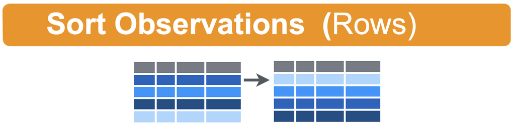

**Example 1:** Order the records based on the UR number in `demographics`.

```r
immuno_dataset$redcap_data$demographics |>
  arrange(ur) |>
  head()
```

| record_id | redcap_event | ur | last_name | first_name | sex | dob | height | weight | bmi | other_studies_enrolled_in | medical_history | autoimmune_disease | select_autoimmune_diseases | smoking |
| --- | --- | --- | --- | --- | --- | --- | --- | --- | --- | --- | --- | --- | --- | --- |
| 216 | baseline | 102028 | Johnson | Catherine | Female | 1979-08-09 | 190 | 103 | 28.53 | mrv | NA | TRUE | inflammatory_bowel_disease | Never smoked |
| 74 | baseline | 112616 | Peterson | Sophie | Male | 1929-09-08 | 161 | 71 | 27.39 | NA | hypertension | TRUE | inflammatory_arthritis | Never smoked |
| 98 | baseline | 113893 | Green | Nathan | Male | 1975-11-29 | 147 | 190 | 87.93 | NA | NA | FALSE | NA | Never smoked |
| 249 | baseline | 121563 | Jones | Jack | Male | 1998-06-06 | 193 | 68 | 18.26 | NA | NA | NA | NA | NA |
| 195 | baseline | 140072 | Foster | Charlotte | Female | 1963-05-19 | 195 | 135 | 35.50 | micromac | NA | FALSE | NA | Never smoked |
| 260 | baseline | 146543 | Barnes | Abigail | Female | 1927-01-16 | 167 | 158 | 56.65 | NA | NA | NA | NA | NA |

**Example 2:** Sort the records in `mortality_data` based on the mortality date first and then by last scan date (`date_last_scan`).

```r
immuno_dataset$redcap_data$mortality_data |>
  arrange(mortality_date, date_last_scan) |>
  head()
```

| record_id | redcap_event | mortality | mortality_date | ongoing_survelliance | date_last_scan | mortality_treatment_time | mortality_cause |
| --- | --- | --- | --- | --- | --- | --- | --- |
| 70 | end | TRUE | 2013-11-15 | no | NA | 45.7 | melanoma progression |
| 193 | end | TRUE | 2015-04-25 | no | NA | NA | melanoma progression |
| 331 | end | TRUE | 2015-05-29 | no | NA | 28.0 | melanoma progression |
| 84 | end | TRUE | 2015-06-19 | no | NA | 0.5 | melanoma progression |
| 349 | end | TRUE | 2015-07-25 | no | 2024-01-17 | 8.5 | melanoma progression |
| 85 | end | FALSE | 2015-08-05 | no | 2018-10-25 | 7.5 | melanoma progression |

#### `desc()` helper function

This function is used to sort data in descending order.

**Example 3:** Sort the records in `mortality_data` in descending order based on the `mortality_treatment_time`.

```r
immuno_dataset$redcap_data$mortality_data |>
  arrange(desc(mortality_treatment_time)) |>
  head()
```

| record_id | redcap_event | mortality | mortality_date | ongoing_survelliance | date_last_scan | mortality_treatment_time | mortality_cause |
| --- | --- | --- | --- | --- | --- | --- | --- |
| 188 | end | FALSE | 2024-09-06 | yes | 2023-12-22 | 131.5 | NA |
| 345 | end | TRUE | 2018-08-03 | no | NA | 115.0 | melanoma progression |
| 221 | end | FALSE | 2024-08-12 | yes | 2024-06-08 | 111.8 | NA |
| 38 | end | FALSE | 2024-04-15 | yes | 2024-06-01 | 109.6 | NA |
| 146 | end | FALSE | 2024-09-06 | no | 2020-08-06 | 108.6 | NA |
| 200 | end | FALSE | 2024-07-12 | no | 2022-01-04 | 108.3 | NA |

**Try It Yourself**

Exclude records where either the first name (`first_name`) or last name (`last_name`) is missing, and then sort the remaining records in ascending order, first by `first_name` and then by `last_name`.

*Hint: Use `demographics` instrument. Use `is.na()` to check for missing values and `!is.na()` to keep only non-missing values.*

**Solution**

```r
immuno_dataset$redcap_data$demographics |>
  filter(!is.na(first_name), !is.na(last_name)) |>
  arrange(first_name, last_name)
```

### `count()` helper

The `count()` function is used to count the number of occurrences of unique values in one or more variables within a data frame. This function is particularly useful for summarising data and understanding the distribution of values within a dataset.

**Example 1:** Count the number of melanoma types in `melanoma_data` data frame.

```r
immuno_dataset$redcap_data$melanoma_data |>
  count(melanoma_type)
```

| melanoma_type | n |
| --- | --- |
| acral | 7 |
| cutaneous | 265 |
| mucosal | 16 |
| pathology_not_available | 4 |
| unknown_primary | 64 |
| uveal | 21 |
| NA | 132 |

**Example 2:** Count the number of records observed in each melanoma type and melanoma molecular mutation.

```r
immuno_dataset$redcap_data$melanoma_data |>
  count(melanoma_type, melanoma_molecular_mutation)
```

| melanoma_type | melanoma_molecular_mutation | n |
| --- | --- | --- |
| acral | braf | 1 |
| acral | kit | 2 |
| acral | nras | 2 |
| acral | wild_type | 1 |
| acral | NA | 1 |
| cutaneous | braf | 110 |
| cutaneous | kit | 3 |
| cutaneous | nras | 54 |
| cutaneous | other | 1 |
| cutaneous | unknown | 3 |
| cutaneous | wild_type | 74 |
| cutaneous | NA | 20 |
| mucosal | braf | 1 |
| mucosal | kit | 3 |
| mucosal | nras | 3 |
| mucosal | wild_type | 9 |
| pathology_not_available | braf | 1 |
| pathology_not_available | nras | 1 |
| pathology_not_available | wild_type | 2 |
| unknown_primary | braf | 30 |
| unknown_primary | kit | 1 |
| unknown_primary | nras | 15 |
| unknown_primary | other | 1 |
| unknown_primary | wild_type | 16 |
| unknown_primary | NA | 1 |
| uveal | braf | 1 |
| uveal | nras | 1 |
| uveal | other | 2 |
| uveal | unknown | 1 |
| uveal | wild_type | 12 |
| uveal | NA | 4 |
| NA | braf | 2 |
| NA | wild_type | 2 |
| NA | NA | 128 |

**Try It Yourself**

Determine the number of records with each single-agent immunotherapy (`type_of_single_agent_io`: ipilimumab, nivolumab, pembrolizumab). Additionally, count the number of patients for each type of best response (`best_response_to_ipi`, `best_response_to_nivo_p`, `best_response_to_pembro`) separately.

*Hint: Use `prior_treatment` instrument.*

**Solution**

```r
immuno_dataset$redcap_data$prior_treatment |> count(type_of_single_agent_io)
```

```r
immuno_dataset$redcap_data$prior_treatment |> count(best_response_to_ipi)
```

```r
immuno_dataset$redcap_data$prior_treatment |> count(best_response_to_nivo)
```

```r
immuno_dataset$redcap_data$prior_treatment |> count(best_response_to_pembro)
```

# Visualising Data

`ggplot2` package simplifies the creation of plots. This package offers a streamlined interface for defining variables to plot, configuring their display, and adjusting visual attributes. Consequently, adapting to changes in the data or transitioning between plot types requires only minimal modifications. This feature facilitates the creation of high-quality plots suitable for publication with minimal manual adjustments.

If you’ve already installed the tidyverse package (if not, you can do so by running the command: `install.packages("tidyverse")`), let’s proceed to load it into our R session first:

```r
library(tidyverse)
```

Next, load the pre-processed RDS Object:

```r
immuno_dataset <- readRDS("data/Sample_immuno_dataset.rds")
```